# DATA 606 - Final Project (Group 5)

# Package Loading

```r
rm(list = ls())
if (!require(pacman)) install.packages('pacman')
p_load(dplyr, caret, ggplot2, ISLR, stringr, tree, MASS, Information, boot,
       tidyverse, rpart, rpart.plot, ROCR, broom, GGally, heplots, tseries, VGAM)
```

# Data Import and Wrangling

## Data Import

```r
chess_df = read.csv('games.csv')
```

## Data Wrangling

### Duplicate Removal

Removal of duplicates based on player matches to avoid duplication.

```r
chess_df$combined = paste(chess_df$white_id, '-', chess_df$black_id, sep = '')
chess_df = chess_df[!duplicated(chess_df$combined), ]
```

### Creating New Features

```r
chess_df$victory_status = toupper(chess_df$victory_status)
chess_df$winner = toupper(chess_df$winner)
chess_df$rated = toupper(chess_df$rated)
chess_df$opening_name = toupper(chess_df$opening_name)

chess_df[c('IC1', 'IC2')] <- str_split_fixed(chess_df$increment_code, '[+]', 2)
chess_df$IC1 = as.numeric(chess_df$IC1)

chess_df = chess_df %>%
  mutate(pace_type = if_else(IC1 < 3, 'BULLET',
                             if_else(IC1 < 15, 'BLITZ', 'STANDARD')))

a = c('W1','B1','W2','B2','W3','B3','W4','B4','W5','B5', 'Rest')
chess_df[a] = str_split_fixed(chess_df$moves, ' ', 11)

chess_df$W_First5 = paste(chess_df$W1, chess_df$W2, chess_df$W3, chess_df$W4,
                          chess_df$W5, sep = '_')
chess_df$B_First5 = paste(chess_df$B1, chess_df$B2, chess_df$B3, chess_df$B4,
                          chess_df$B5, sep = '_')

chess_df$Rating_WB = chess_df$white_rating/chess_df$black_rating

chess_df = chess_df %>%
  mutate(rating_bins = ifelse(Rating_WB<=0.9,
                              "Black Favoured",
                              ifelse(Rating_WB>=1.1,
                                     "White Favoured",
                                     "Equal")))

chess_df = chess_df %>% dplyr::select(-c('id', 'white_id', 'black_id','opening_eco',
                                  'opening_ply', 'combined', 'created_at',
                                  'last_move_at', 'created_at', 'last_move_at',
                                  'increment_code', 'IC1', 'IC2', 'W2','B2','W3',
                                  'B3','W4','B4','W5','B5', 'Rest', 'moves',
                                  'white_rating', 'black_rating'))

chess_df = chess_df %>%
  mutate(opening_strategy = if_else(grepl('DEFENSE',
                                          chess_df$opening_name,
                                          fixed = TRUE) == TRUE,
                                    'DEFENSE',
                                    'NO_DEFENSE'))


a = c('P1', 'P2', 'P3')
chess_df[a] = str_split_fixed(chess_df$opening_name, ':', 3)
chess_df = chess_df %>% dplyr::select(-c('P2', 'P3'))

a = c('P11', 'P12', 'P13')
chess_df[a] = str_split_fixed(chess_df$P1, ' #', 3)
chess_df = chess_df %>% dplyr::select(-c('P1', 'P12', 'P13'))

a = c('P21', 'P22')
chess_df[a] = str_split_fixed(chess_df$P11, '[|]', 2)
chess_df = chess_df %>% dplyr::select(-c('P11', 'P22'))

chess_df = chess_df %>%
  group_by(P21) %>%
  mutate(count=n()) %>%
  mutate(op_name = if_else(count < 50, 'OTHER', P21)) %>%
  ungroup()

chess_df = chess_df %>% dplyr::select(-c('P21', 'count', 'opening_name'))
```

### Data Wrangling for Question 1

```r
chess_df_q1 = chess_df %>% filter(winner != 'DRAW')
```

### Weight of Evidence Calculations

```r
chess_df_q1 =  as.data.frame(unclass(chess_df_q1), stringsAsFactors = TRUE)

chess_df_q1 = chess_df_q1 %>%
  mutate(target_y = if_else(winner == 'BLACK', 0, 1))
IV = create_infotables(data=chess_df_q1, y='target_y')
```

```
[1] "Variable W_First5 was removed because it is a non-numeric variable with >1000 categories"
[1] "Variable B_First5 was removed because it is a non-numeric variable with >1000 categories"
```

```r
WOE_List = c('op_name', 'W1', 'B1')
for (i in 1:length(WOE_List)){
  assign(paste0('WOE_Temp'),
         eval(parse(text = paste0('IV$Tables$',WOE_List[i]))))
  WOE_Temp = WOE_Temp %>% dplyr::select(-c('N', 'Percent', 'IV'))
  names(WOE_Temp)[2] = paste('WOE_', WOE_List[i], sep = '')
  chess_df_q1 = merge(chess_df_q1,WOE_Temp,by=WOE_List[i], all.x = TRUE)
}

chess_df_q3 = chess_df_q1 %>% dplyr::select(c('winner', 'W1', 'WOE_W1'))
chess_df_q3 =  as.data.frame(unclass(chess_df_q3), stringsAsFactors = TRUE)

chess_df_q1 = chess_df_q1 %>% dplyr::select(-c('victory_status', 'target_y',
                                               'op_name', 'W1', 'B1',
                                               'W_First5', 'B_First5'))
chess_df_q1 =  as.data.frame(unclass(chess_df_q1), stringsAsFactors = TRUE)

chess_df_q2 = chess_df %>% dplyr::select(-c('winner', 'op_name'))
chess_df_q2 =  as.data.frame(unclass(chess_df_q2), stringsAsFactors = TRUE)
```

### CSV file for Question 1

```r
write.csv(chess_df_q1, 'Chess_data_q1.csv')
```

### CSV file for Question 2

```r
write.csv(chess_df_q2, 'chess_df_overall.csv')
```

```r
write.csv(chess_df_q1, 'Chess_data_q1.csv')
```

# Exploratory Data Analysis

## Univariate Analysis

```r
summary(chess_df_q1)
```

```
   rated           turns          winner        pace_type       Rating_WB
 FALSE: 2953   Min.   :  1.00   BLACK:8100   BLITZ   :11934   Min.   :0.3876
 TRUE :14057   1st Qu.: 37.00   WHITE:8910   BULLET  :  103   1st Qu.:0.9357
               Median : 55.00                STANDARD: 4973   Median :1.0020
               Mean   : 59.73                                 Mean   :1.0171
               3rd Qu.: 77.00                                 3rd Qu.:1.0786
               Max.   :349.00                                 Max.   :2.5772
         rating_bins      opening_strategy  WOE_op_name            WOE_W1
 Black Favoured: 3026   DEFENSE   :9688    Min.   :-0.783180   Min.   :-1.2992830
 Equal         :10415   NO_DEFENSE:7322    1st Qu.:-0.157890   1st Qu.: 0.0078317
 White Favoured: 3569                      Median :-0.039221   Median : 0.0223411
                                           Mean   : 0.001338   Mean   :-0.0007669
                                           3rd Qu.: 0.133698   3rd Qu.: 0.0223411
                                           Max.   : 0.740012   Max.   : 0.5978370
     WOE_B1
 Min.   :-0.1693578
 1st Qu.:-0.0864212
 Median : 0.0155376
 Mean   : 0.0006236
 3rd Qu.: 0.0619085
 Max.   : 1.8506000
```

```r
summary(chess_df_q2)
```

```
   rated           turns          victory_status    pace_type           W1
 FALSE: 3124   Min.   :  1.00   DRAW     : 776   BLITZ   :12462   e4     :11265
 TRUE :14702   1st Qu.: 38.00   MATE     :5542   BULLET  :  106   d4     : 4089
               Median : 56.00   OUTOFTIME:1513   STANDARD: 5258   c4     :  626
               Mean   : 61.04   RESIGN   :9995                    Nf3    :  608
               3rd Qu.: 79.00                                     e3     :  337
               Max.   :349.00                                     g3     :  154
                                                                  (Other):  747
       B1                      W_First5                   B_First5       Rating_WB
 e5     :6204   e4_Nf3_d4_Nxd4_Nc3 :  433   c5_d6_cxd4_Nf6_a6 :  143   Min.   :0.3876
 d5     :3280   e4_Nf3_d4_Nxd4_Qxd4:  118   Nf6_g6_Bg7_d6_O-O :  116   1st Qu.:0.9363
 c5     :2586   e4_Nf3_Bc4_Ng5_exd5:  105   e5_Nc6_Nf6_d5_Nxd5:   93   Median :1.0017
 e6     :1853   e4_Nf3_d4_Nxd4_Nxc6:   92   Nf6_g6_Bg7_O-O_d6 :   82   Mean   :1.0169
 Nf6    :1508   e4_d4_e5_c3_Nf3    :   87   e5_Nc6_Bc5_Nf6_O-O:   75   3rd Qu.:1.0773
 c6     : 645   e4_Nf3_Bc4_Nc3_d3  :   87   e6_d5_c5_Nc6_Qb6  :   73   Max.   :2.5772
 (Other):1750   (Other)            :16904   (Other)           :17244
         rating_bins      opening_strategy
 Black Favoured: 3142   DEFENSE   :10177
 Equal         :10988   NO_DEFENSE: 7649
 White Favoured: 3696
```

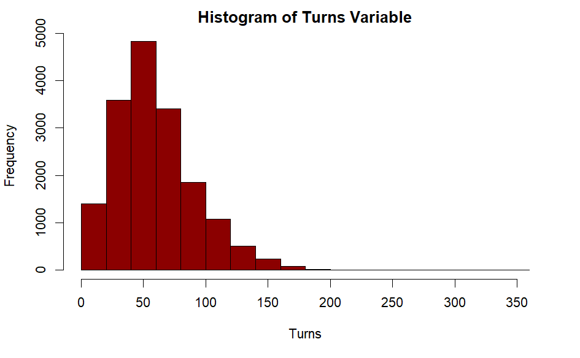

```r
hist(chess_df_q1$turns,
     col = 'darkred',
     main = 'Histogram of Turns Variable',
     xlab = 'Turns')
```

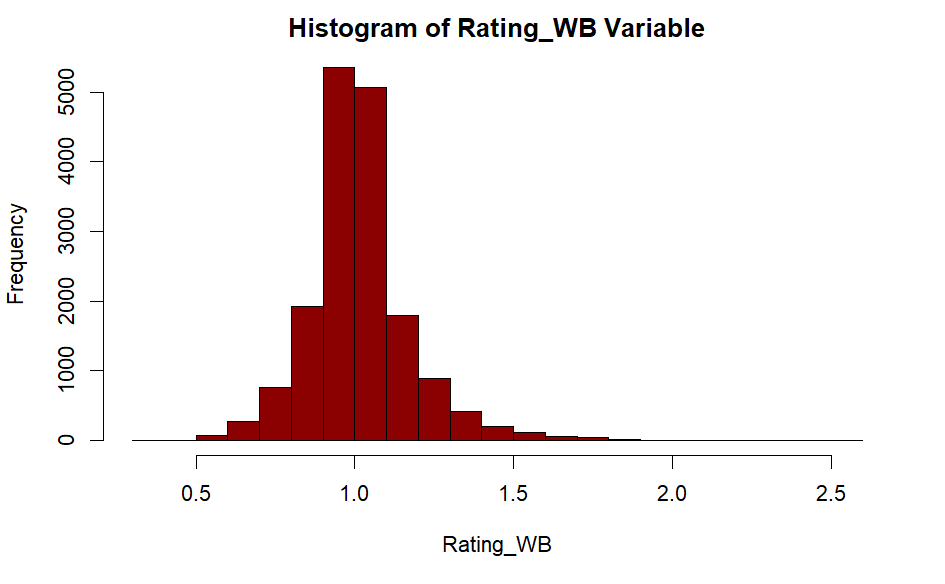

```r
hist(chess_df_q1$Rating_WB,
     col = 'darkred',
     main = 'Histogram of Rating_WB Variable',
     xlab = 'Rating_WB')
```

## Bivariate Analysis

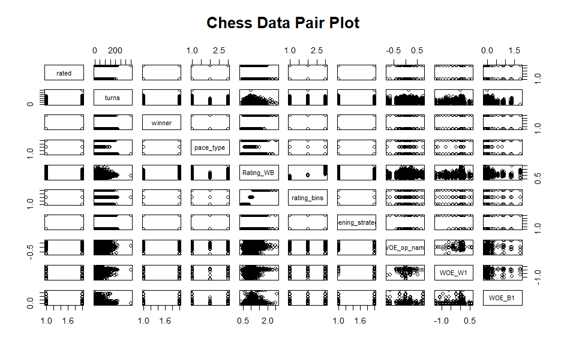

```r
plot(chess_df_q1,
     main = 'Chess Data Pair Plot')
```

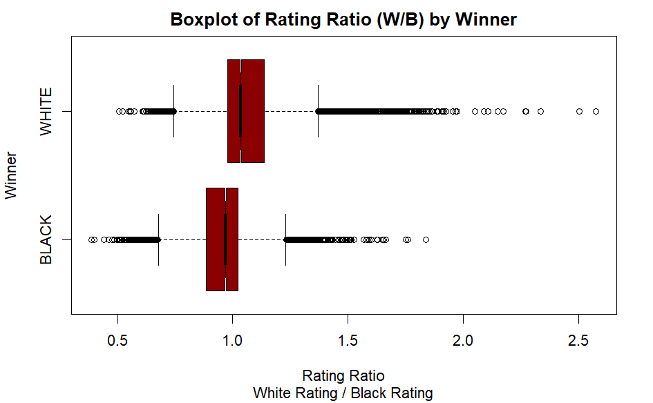

```r
chess_df_q1 %>%
  dplyr::select(Rating_WB,winner) %>%
  boxplot(Rating_WB ~ winner,
          data = .,
          horizontal = T, #horizontal plot
          notch = T, # CI for median
          main = "Boxplot of Rating Ratio (W/B) by Winner",
          sub = "White Rating / Black Rating",
          xlab = "Rating Ratio",
          ylab = 'Winner',
          col = "darkred"
  )
```

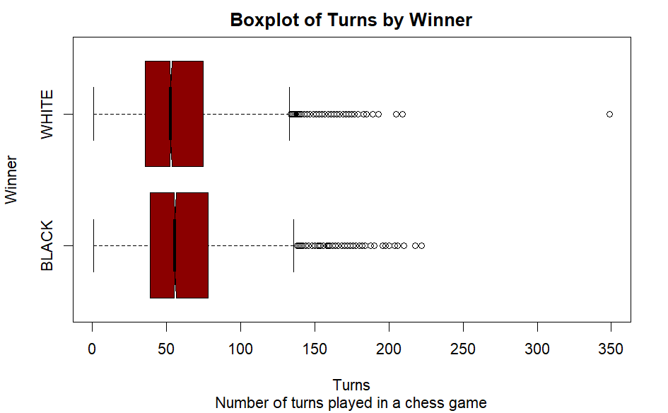

```r
chess_df_q1 %>%
  dplyr::select(turns, winner) %>%
  boxplot(turns ~ winner,
          data = .,
          horizontal = T, #horizontal plot
          notch = T, # CI for median
          main = "Boxplot of Turns by Winner",
          sub = "Number of turns played in a chess game",
          xlab = "Turns",
          ylab = 'Winner',
          col = "darkred"
  )
```

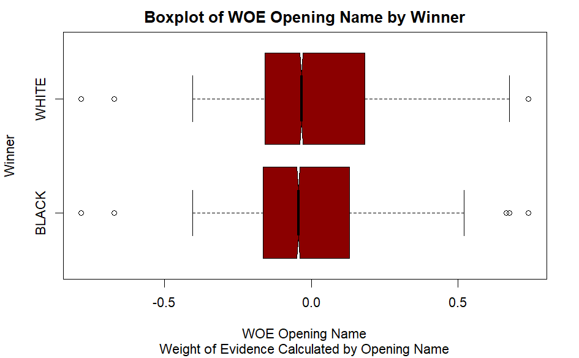

```r
chess_df_q1 %>%
  dplyr::select(WOE_op_name, winner) %>%
  plot(WOE_op_name ~ winner,
          data = .,
          horizontal = T, #horizontal plot
          notch = T, # CI for median
          main = "Boxplot of WOE Opening Name by Winner",
          sub = "Weight of Evidence Calculated by Opening Name",
          xlab = "Winner",
          ylab = 'WOE Opening Name',
          col = "darkred"
  )
```

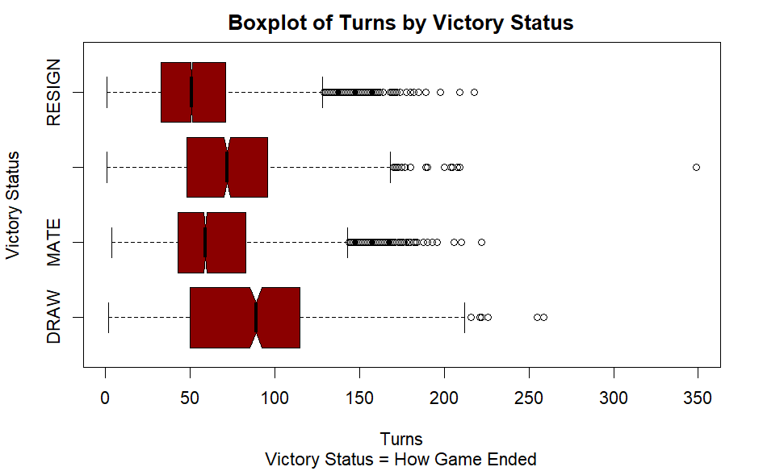

```r
chess_df_q2 %>%
  dplyr::select(turns, victory_status) %>%
  plot(turns ~ victory_status,
          data = .,
          horizontal = T, #horizontal plot
          notch = T, # CI for median
          main = "Boxplot of Turns by Victory Status",
          sub = "Victory Status = How Game Ended",
          xlab = "Victory Status",
          ylab = 'Turns',
          col = "darkred"
  )
```

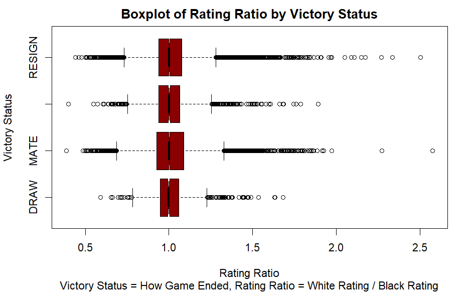

```r
chess_df_q2 %>%
  dplyr::select(Rating_WB, victory_status) %>%
  plot(Rating_WB ~ victory_status,
          data = .,
          horizontal = T, #horizontal plot
          notch = T, # CI for median
          main = "Boxplot of Rating Ratio by Victory Status",
          sub = "Victory Status = How Game Ended, Rating Ratio = White Rating / Black Rating",
          xlab = "Victory Status",
          ylab = 'Rating Ratio',
          col = "darkred"
  )
```

# Question 1

## Stratified Train - Test Split

```r
set.seed(5)
idx = createDataPartition(chess_df_q1$rating_bins, p = .75, list = FALSE)
train_q1 <- chess_df_q1[ idx,]
test_q1  <- chess_df_q1[-idx,]

rownames(train_q1) = 1:nrow(train_q1)
rownames(test_q1) = 1:nrow(test_q1)
```

## Decision Tree

### Additional Data Processing

Not required

### Model Assumptions

No Assumptions

### Model Train with k-fold Cross Validation

#### Model Train

```r
fit_formula = winner ~ rated + turns + pace_type + WOE_W1 + WOE_B1 +
  opening_strategy + WOE_op_name + rating_bins

tree_q1 = rpart(fit_formula, data = train_q1, method="class")
```

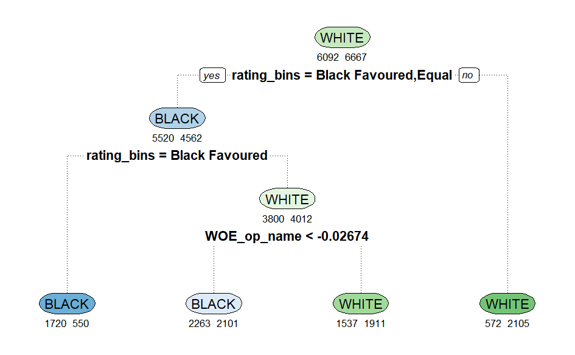

```r
rpart.plot(tree_q1,
           type = 2,
           extra =1,
           under = TRUE,
           branch.lty=3, digits = 4)
```

#### Cross Validation Error

```r
set.seed(5)
folds = createFolds(train_q1$winner, k=10)

misclassification<-function(idx){
  temp_train = train_q1[-idx,]
  temp_test = train_q1[idx,]
  tree_model = rpart(fit_formula, data = temp_train, method="class")
  pred = predict(tree_model,temp_test, type="class")
  actual = temp_test$winner
  conf = table(pred, actual)
  1 - sum(diag(conf)) / sum(conf)
}
CV_Tree_Q1 = mean(as.numeric(lapply(folds, misclassification)))
CV_Tree_Q1
```

```
[1] 0.3749493
```

### Model Performance on Test Dataset

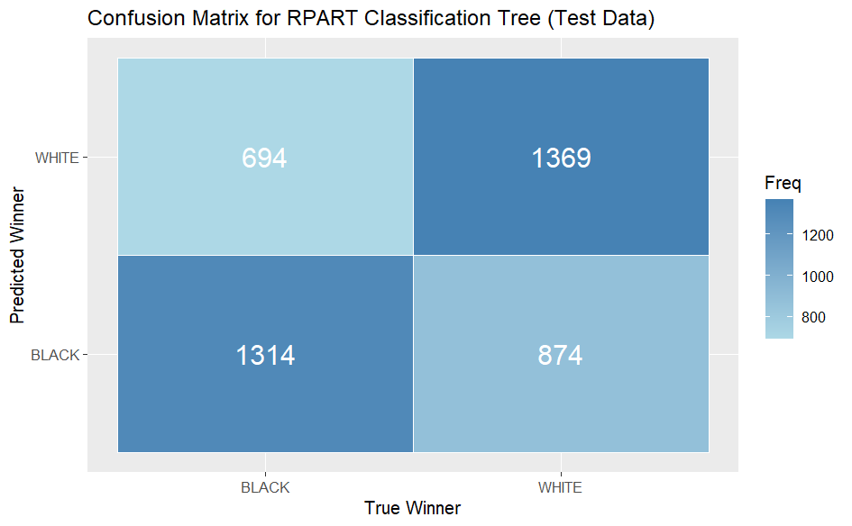

```r
q1_tree_pred = predict(tree_q1, test_q1, type = 'class')
actual_q1 = test_q1$winner
table = table(q1_tree_pred, actual_q1)
ggplot(as.data.frame(table), aes(x = actual_q1, y = q1_tree_pred)) +
  geom_tile(aes(fill = Freq), colour = "white") +
  scale_fill_gradient(low = "lightblue", high = "steelblue") +
  geom_text(aes(label = Freq), color = "white", size = 6) +
  xlab("True Winner") +
  ylab("Predicted Winner") +
  ggtitle("Confusion Matrix for RPART Classification Tree (Test Data)")
```

```r
Accuracy_Tree_Q1 = sum(diag(table)) / sum(table)
paste('The Accuracy value of RPART Tree is:', Accuracy_Tree_Q1, sep = ' ')
```

```
[1] "The Accuracy value of RPART Tree is: 0.631145612796989"
```

#### Performance Metrics

```r
confusionMatrix(table, positive = 'WHITE')
```

```
Confusion Matrix and Statistics

            actual_q1
q1_tree_pred BLACK WHITE
       BLACK  1314   874
       WHITE   694  1369

               Accuracy : 0.6311
                 95% CI : (0.6164, 0.6457)
    No Information Rate : 0.5276
    P-Value [Acc > NIR] : < 2.2e-16

                  Kappa : 0.2635

 Mcnemar's Test P-Value : 6.171e-06

            Sensitivity : 0.6103
            Specificity : 0.6544
         Pos Pred Value : 0.6636
         Neg Pred Value : 0.6005
             Prevalence : 0.5276
         Detection Rate : 0.3220
   Detection Prevalence : 0.4853
      Balanced Accuracy : 0.6324

       'Positive' Class : WHITE
```

#### ROC Curve and AUC Calculations

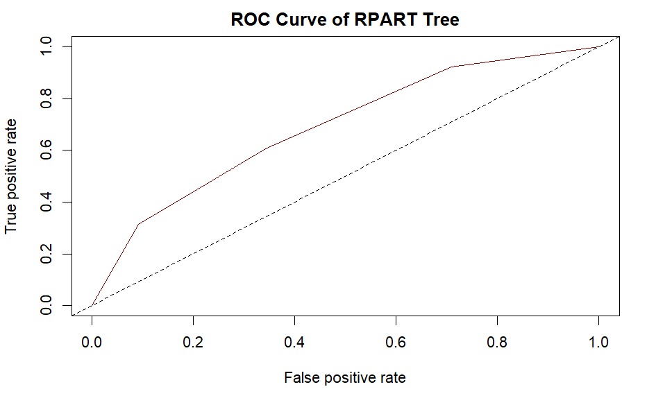

```r
tree_prob_pred = prediction(predict(tree_q1, test_q1, type = 'prob')[, 2],
                            test_q1$winner)

plot(performance(tree_prob_pred, "tpr", "fpr"),
     main = 'ROC Curve of RPART Tree',
     col = 'darkred')
abline(0, 1, lty = 2)
```

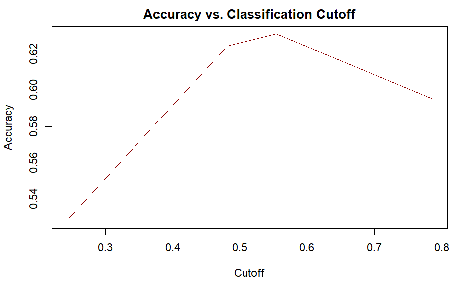

```r
plot(performance(tree_prob_pred, "acc"),
     main = 'Accuracy vs. Classification Cutoff',
     col = 'darkred')
```

```r
auc_tree = performance(tree_prob_pred, measure = "auc")
paste('The AUC value of RPART Tree is:', auc_tree@y.values[[1]], sep = ' ')
```

```
[1] "The AUC value of RPART Tree is: 0.690289999165176"
```

## Logistic Regression

### Additional Data Processing

Not required

### Model Train

#### Full Model

```r
fit_formula_q1_log = winner ~ rated + turns + pace_type + WOE_W1 + WOE_B1 +
  Rating_WB + opening_strategy + WOE_op_name

log_reg_full = glm(fit_formula_q1_log, data=train_q1, family=binomial)
summary(log_reg_full)
```

```
Call:
glm(formula = fit_formula_q1_log, family = binomial, data = train_q1)

Deviance Residuals:
    Min       1Q   Median       3Q      Max
-3.0311  -1.0853   0.3884   1.0698   2.5249

Coefficients:
                             Estimate Std. Error z value Pr(>|z|)
(Intercept)                -5.5966937  0.1746885 -32.038  < 2e-16 ***
ratedTRUE                   0.0006636  0.0527052   0.013   0.9900
turns                      -0.0023900  0.0006012  -3.975 7.02e-05 ***
pace_typeBULLET             0.0315890  0.2579821   0.122   0.9025
pace_typeSTANDARD           0.0224704  0.0424622   0.529   0.5967
WOE_W1                      0.2253540  0.1486929   1.516   0.1296
WOE_B1                      0.3301912  0.1613185   2.047   0.0407 *
Rating_WB                   5.7831877  0.1622101  35.652  < 2e-16 ***
opening_strategyNO_DEFENSE -0.0230633  0.0398965  -0.578   0.5632
WOE_op_name                 0.6753146  0.0978045   6.905 5.03e-12 ***
---
Signif. codes:  0 ‘***’ 0.001 ‘**’ 0.01 ‘*’ 0.05 ‘.’ 0.1 ‘ ’ 1

(Dispersion parameter for binomial family taken to be 1)

    Null deviance: 17662  on 12758  degrees of freedom
Residual deviance: 15673  on 12749  degrees of freedom
AIC: 15693

Number of Fisher Scoring iterations: 4
```

#### Reduced Model

```r
fit_formula_q1_log = winner ~ turns + WOE_B1 + Rating_WB + WOE_op_name

log_reg_reduced = glm(fit_formula_q1_log, data=train_q1, family=binomial)
summary(log_reg_reduced)
```

```
Call:
glm(formula = fit_formula_q1_log, family = binomial, data = train_q1)

Deviance Residuals:
    Min       1Q   Median       3Q      Max
-3.0320  -1.0865   0.3893   1.0713   2.4814

Coefficients:
              Estimate Std. Error z value Pr(>|z|)
(Intercept) -5.6111495  0.1671828 -33.563  < 2e-16 ***
turns       -0.0023679  0.0005983  -3.958 7.57e-05 ***
WOE_B1       0.2658239  0.1553403   1.711    0.087 .
Rating_WB    5.7940540  0.1620974  35.744  < 2e-16 ***
WOE_op_name  0.7400969  0.0889065   8.324  < 2e-16 ***
---
Signif. codes:  0 ‘***’ 0.001 ‘**’ 0.01 ‘*’ 0.05 ‘.’ 0.1 ‘ ’ 1

(Dispersion parameter for binomial family taken to be 1)

    Null deviance: 17662  on 12758  degrees of freedom
Residual deviance: 15677  on 12754  degrees of freedom
AIC: 15687

Number of Fisher Scoring iterations: 4
```

```r
fit_formula_q1_log = winner ~ turns + Rating_WB + WOE_op_name

log_reg_reduced = glm(fit_formula_q1_log, data=train_q1, family=binomial)
summary(log_reg_reduced)
```

```
Call:
glm(formula = fit_formula_q1_log, family = binomial, data = train_q1)

Deviance Residuals:
    Min       1Q   Median       3Q      Max
-3.0456  -1.0863   0.3909   1.0718   2.4928

Coefficients:
              Estimate Std. Error z value Pr(>|z|)
(Intercept) -5.6194996  0.1671335 -33.623  < 2e-16 ***
turns       -0.0024221  0.0005974  -4.055 5.02e-05 ***
Rating_WB    5.8046738  0.1619864  35.834  < 2e-16 ***
WOE_op_name  0.7875377  0.0846339   9.305  < 2e-16 ***
---
Signif. codes:  0 ‘***’ 0.001 ‘**’ 0.01 ‘*’ 0.05 ‘.’ 0.1 ‘ ’ 1

(Dispersion parameter for binomial family taken to be 1)

    Null deviance: 17662  on 12758  degrees of freedom
Residual deviance: 15680  on 12755  degrees of freedom
AIC: 15688

Number of Fisher Scoring iterations: 4
```

### Model Assumptions

#### Independence

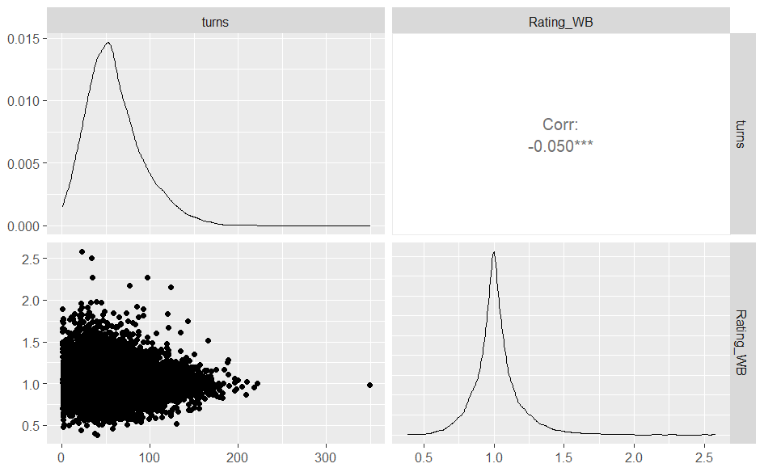

```r
my_data = train_q1 %>% dplyr::select(c(turns, Rating_WB))
ggpairs(my_data)
```

#### Linearity

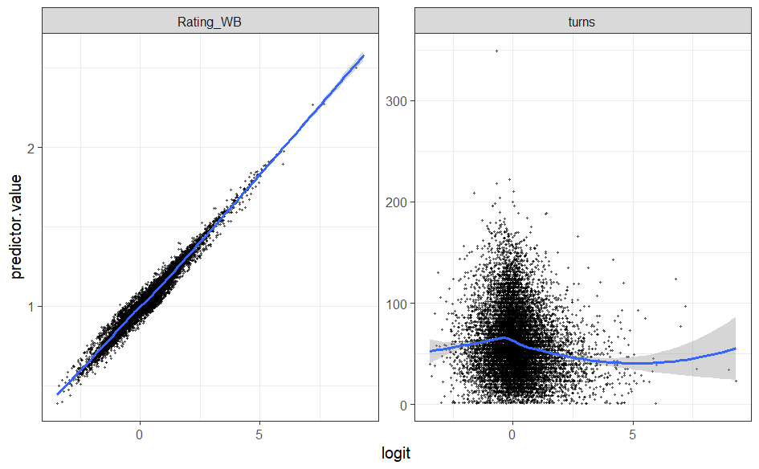

```r
pred_prob = predict(log_reg_reduced, type = "response")

my_data = train_q1 %>% dplyr::select(c(Rating_WB, turns))
predictors = colnames(my_data)

my_data <- my_data %>%
  mutate(logit = log(pred_prob/(1-pred_prob))) %>%
  gather(key = "predictors", value = "predictor.value", -logit)

ggplot(my_data, aes(logit, predictor.value))+
  geom_point(size = 0.5, alpha = 0.5) +
  geom_smooth(method = "loess") +
  theme_bw() +
  facet_wrap(~predictors, scales = "free_y")
```

#### Outlier Detection

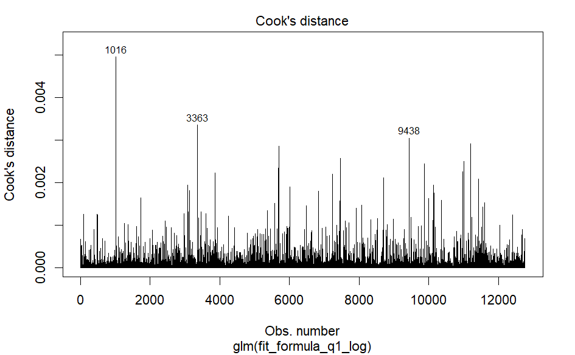

```r
plot(log_reg_reduced, which = 4, id.n = 3)
```

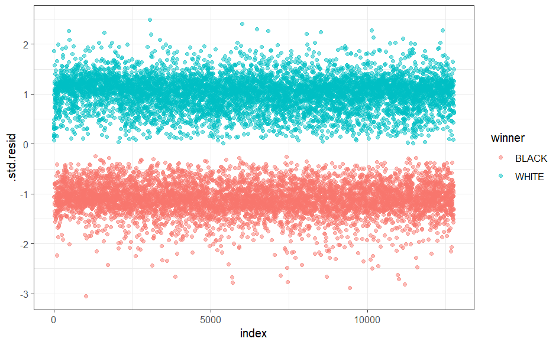

```r
model_data <- augment(log_reg_reduced) %>%
  mutate(index = 1:n())

outlier_rows = model_data %>%
  top_n(3, .cooksd) %>%
  dplyr::select(index) %>%
  unlist() %>% as.integer()

ggplot(model_data, aes(index, .std.resid)) +
  geom_point(aes(color = winner), alpha = .5) +
  theme_bw()
```

#### Multicollinearity

```r
car::vif(log_reg_reduced)
```

```
      turns   Rating_WB WOE_op_name
   1.000102    1.001437    1.001389
```

### Model Re-Train and k-fold Cross Validation

#### Re-Train

```r
train_q1_cleaned = train_q1[-outlier_rows,]
```

```r
fit_formula_q1_log = winner ~ Rating_WB + WOE_op_name

log_reg_final = glm(fit_formula_q1_log, data=train_q1_cleaned, family=binomial)
summary(log_reg_final)
```

```
Call:
glm(formula = fit_formula_q1_log, family = binomial, data = train_q1_cleaned)

Deviance Residuals:
    Min       1Q   Median       3Q      Max
-2.7965  -1.0897   0.3959   1.0727   2.5028

Coefficients:
            Estimate Std. Error z value Pr(>|z|)
(Intercept) -5.80647    0.16377 -35.454   <2e-16 ***
Rating_WB    5.84485    0.16225  36.023   <2e-16 ***
WOE_op_name  0.78663    0.08467   9.291   <2e-16 ***
---
Signif. codes:  0 ‘***’ 0.001 ‘**’ 0.01 ‘*’ 0.05 ‘.’ 0.1 ‘ ’ 1

(Dispersion parameter for binomial family taken to be 1)

    Null deviance: 17658  on 12755  degrees of freedom
Residual deviance: 15677  on 12753  degrees of freedom
AIC: 15683

Number of Fisher Scoring iterations: 4
```

#### Cross Validation To Determine Best Cut-Off

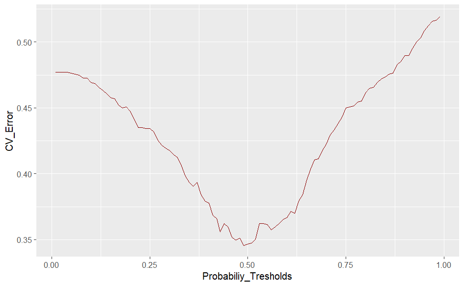

```r
set.seed(5)
folds_class = createFolds(train_q1_cleaned$winner, k=10)

CV_Error = rep(0,99)

log_reg_treshold = seq(0.01, 0.99, 0.01)

for (i in 1:99){
  p_tresh = log_reg_treshold[i]
  err = rep(0,10)
  for (j in 1:10){
    assign(paste0('temp_train'), train_q1_cleaned[-eval(parse(text = paste0('folds_class$Fold0',1))),])
    assign(paste0('temp_validation'), train_q1_cleaned[eval(parse(text = paste0('folds_class$Fold0',1))),])
    temp_log_reg = glm(fit_formula_q1_log, data = temp_train, family = 'binomial')
    temp_probs = predict(temp_log_reg, temp_validation, type="response")
    actual = temp_validation$winner
    predicted = rep('BLACK', nrow(temp_validation))
    predicted[temp_probs >= p_tresh] = 'WHITE'
    err[j] = 1-mean(predicted==actual)
  }
  CV_Error[i] = mean(err)
}

CV_Result = data.frame(Probabiliy_Tresholds = log_reg_treshold, CV_Error)

ggplot()+
  geom_line(data = CV_Result, aes(Probabiliy_Tresholds, CV_Error), colour='darkred')
```

```r
CV_Result %>% filter(CV_Error == min(CV_Error))
```

| Probabiliy_Tresholds | CV_Error |
| --- | --- |
| 0.49 | 0.3456113 |

```r
CV_Error_LogReg = CV_Result %>%
  filter(CV_Error == min(CV_Error)) %>%
  dplyr::select(CV_Error) %>%
  as.double()
```

### Model Performance on Test Dataset

```r
cut_off = 0.49
```

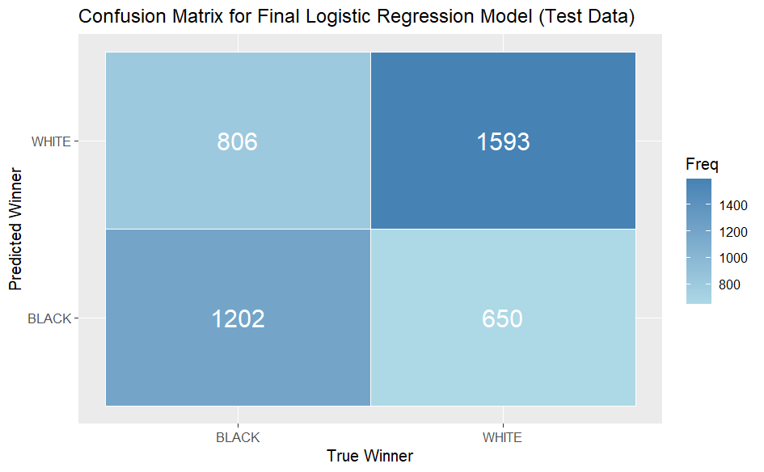

```r
pred_prob_logreg = predict(log_reg_final, test_q1, type="response")
predicted_logreg = rep('BLACK', nrow(test_q1))
predicted_logreg[pred_prob_logreg >= cut_off] = 'WHITE'

table = table(predicted_logreg, actual_q1)
ggplot(as.data.frame(table), aes(x = actual_q1, y = predicted_logreg)) +
  geom_tile(aes(fill = Freq), colour = "white") +
  scale_fill_gradient(low = "lightblue", high = "steelblue") +
  geom_text(aes(label = Freq), color = "white", size = 6) +
  xlab("True Winner") +
  ylab("Predicted Winner") +
  ggtitle("Confusion Matrix for Final Logistic Regression Model (Test Data)")
```

```r
Accuracy_LogReg_Q1 = sum(diag(table)) / sum(table)
paste('The Accuracy value of LogReg is:', Accuracy_LogReg_Q1, sep = ' ')
```

```
[1] "The Accuracy value of LogReg is: 0.657492354740061"
```

#### Performance Metrics

```r
confusionMatrix(table, positive = 'WHITE')
```

```
Confusion Matrix and Statistics

                actual_q1
predicted_logreg BLACK WHITE
           BLACK  1202   650
           WHITE   806  1593

               Accuracy : 0.6575
                 95% CI : (0.643, 0.6718)
    No Information Rate : 0.5276
    P-Value [Acc > NIR] : < 2.2e-16

                  Kappa : 0.3101

 Mcnemar's Test P-Value : 4.863e-05

            Sensitivity : 0.7102
            Specificity : 0.5986
         Pos Pred Value : 0.6640
         Neg Pred Value : 0.6490
             Prevalence : 0.5276
         Detection Rate : 0.3747
   Detection Prevalence : 0.5643
      Balanced Accuracy : 0.6544

       'Positive' Class : WHITE
```

#### ROC Curve and AUC Calculations

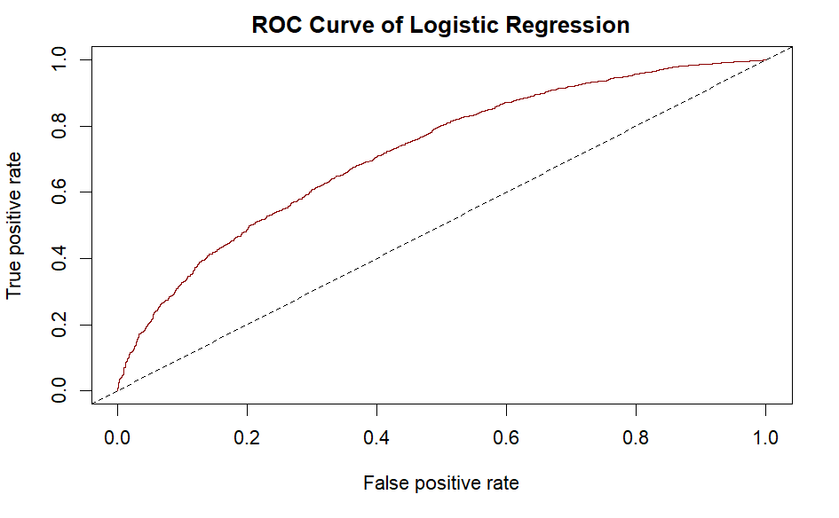

```r
plot(performance(prediction(pred_prob_logreg, actual_q1), "tpr", "fpr"),
     main = 'ROC Curve of Logistic Regression',
     col = 'darkred')
abline(0, 1, lty = 2)
```

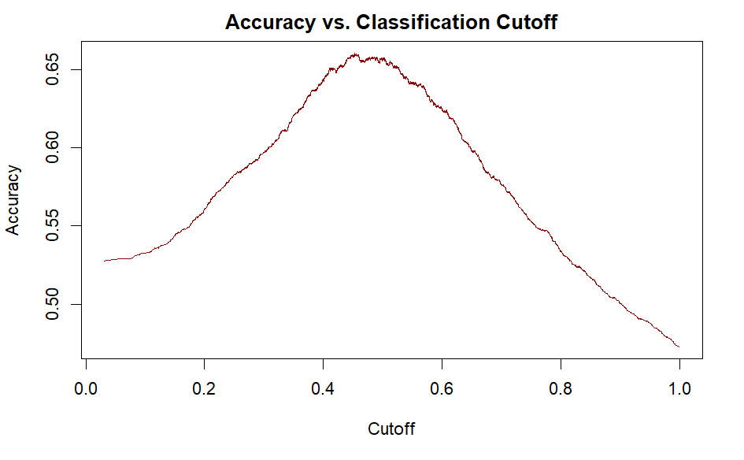

```r
plot(performance(prediction(pred_prob_logreg, actual_q1), "acc"),
     main = 'Accuracy vs. Classification Cutoff',
     col = 'darkred')
```

```r
auc_log_reg = performance(prediction(pred_prob_logreg, actual_q1), "auc")
paste('The AUC value of RPART Tree is:', auc_log_reg@y.values[[1]], sep = ' ')
```

```
[1] "The AUC value of RPART Tree is: 0.720901947271102"
```

## Linear Discriminant Analysis

### Additional Data Processing

Not required

### Model Assumptions

#### Normality with Actual Data

```r
df2.white<-subset(chess_df_q1,winner =="WHITE")
df2.black<-subset(chess_df_q1,winner =="BLACK")
```

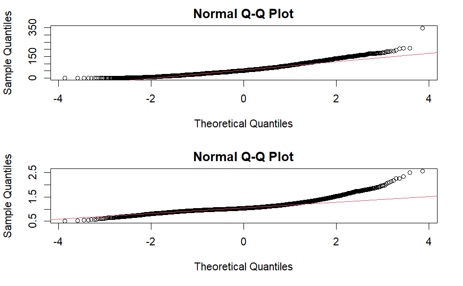

```r
#Q-Q plot for level "WHITE"
variable_1<-c("turns","Rating_WB")
par(mfrow = c(2,1))

for(i in variable_1) {
  qqnorm(df2.white[[i]]);qqline(df2.white[[i]],col=2)}
```

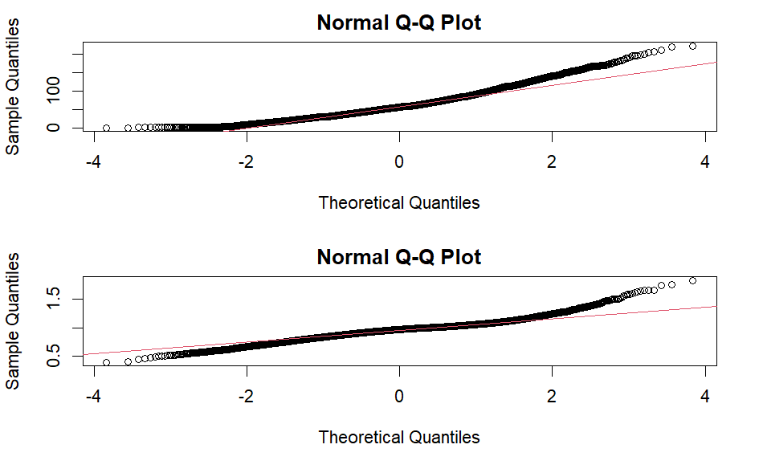

```r
par(mfrow = c(2,1))
for(i in variable_1) {
  qqnorm(df2.black[[i]]);qqline(df2.black[[i]],col=2)}
```

```r
jarque.bera.test(df2.white$turns)
```

```
    Jarque Bera Test

data:  df2.white$turns
X-squared = 1979.1, df = 2, p-value < 2.2e-16
```

```r
jarque.bera.test(df2.white$Rating_WB)
```

```
    Jarque Bera Test

data:  df2.white$Rating_WB
X-squared = 16254, df = 2, p-value < 2.2e-16
```

```r
jarque.bera.test(df2.black$turns)
```

```
    Jarque Bera Test

data:  df2.black$turns
X-squared = 1302.7, df = 2, p-value < 2.2e-16
```

```r
jarque.bera.test(df2.black$Rating_WB)
```

```
    Jarque Bera Test

data:  df2.black$Rating_WB
X-squared = 2232.4, df = 2, p-value < 2.2e-16
```

#### Normality with log Transform

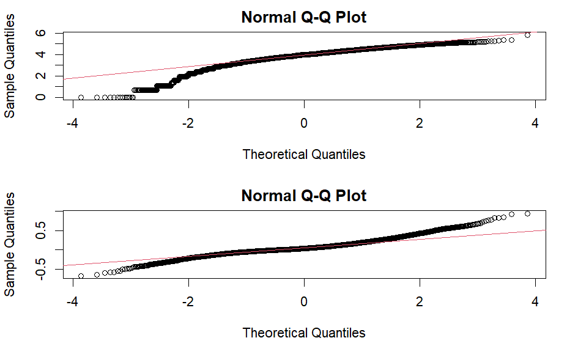

```r
#Q-Q plot for level "WHITE"
variable_1<-c("turns","Rating_WB")
par(mfrow = c(2,1))

for(i in variable_1) {
  qqnorm(log(df2.white[[i]]));qqline(log(df2.white[[i]]),col=2)}
```

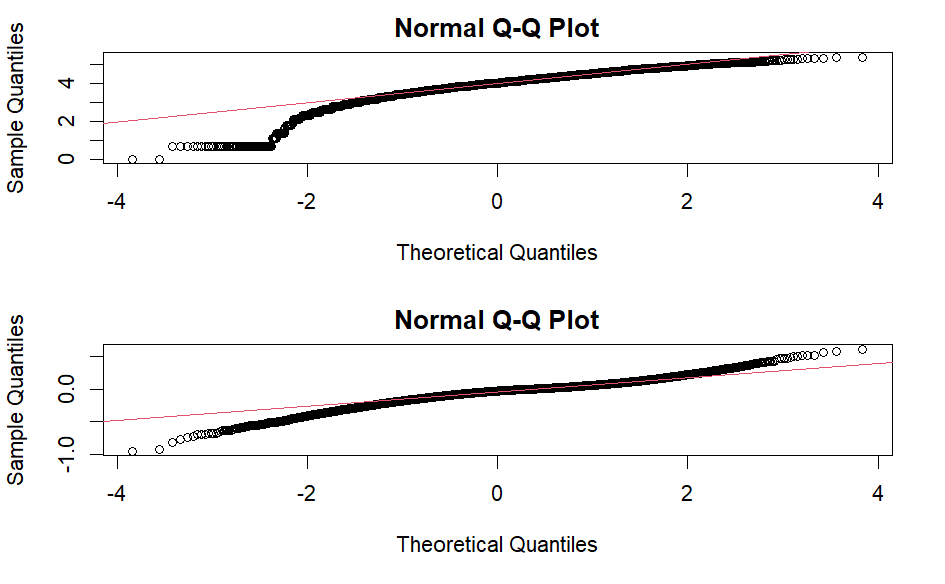

```r
par(mfrow = c(2,1))
for(i in variable_1) {
  qqnorm(log(df2.black[[i]]));qqline(log(df2.black[[i]]),col=2)}
```

```r
jarque.bera.test(log(df2.white$turns))
```

```
    Jarque Bera Test

data:  log(df2.white$turns)
X-squared = 9978.4, df = 2, p-value < 2.2e-16
```

```r
jarque.bera.test(log(df2.white$Rating_WB))
```

```
    Jarque Bera Test

data:  log(df2.white$Rating_WB)
X-squared = 2998.8, df = 2, p-value < 2.2e-16
```

```r
jarque.bera.test(log(df2.black$turns))
```

```
    Jarque Bera Test

data:  log(df2.black$turns)
X-squared = 12986, df = 2, p-value < 2.2e-16
```

```r
jarque.bera.test(log(df2.black$Rating_WB))
```

```
    Jarque Bera Test

data:  log(df2.black$Rating_WB)
X-squared = 2628.6, df = 2, p-value < 2.2e-16
```

#### Equal Covariance

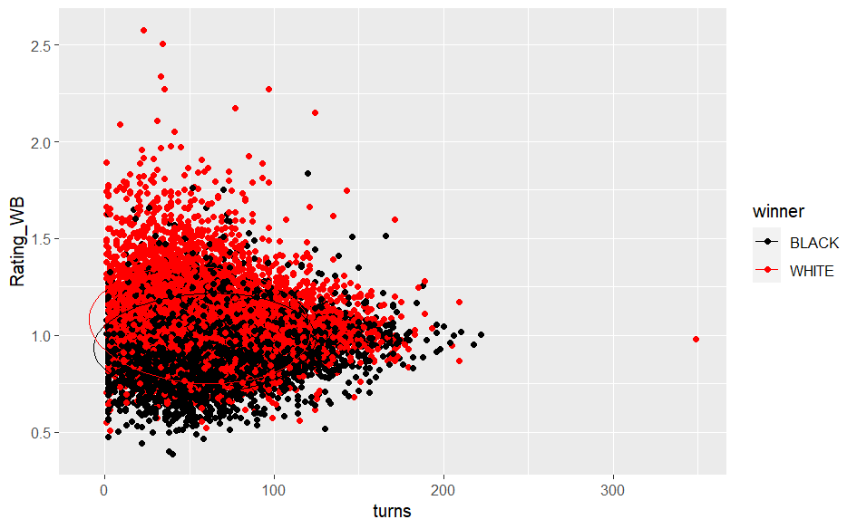

```r
ggplot(chess_df_q1, aes(x = turns, y = Rating_WB, col = winner)) +
    geom_point() +
    stat_ellipse() +
    scale_color_manual(values = c("black", "red"))
```

```r
new_data = chess_df_q1 %>% dplyr::select(c(turns, Rating_WB))
boxq1 = heplots::boxM(new_data, chess_df_q1$winner)
boxq1
```

```
    Box's M-test for Homogeneity of Covariance Matrices

data:  new_data
Chi-Sq (approx.) = 662.96, df = 3, p-value < 2.2e-16
```

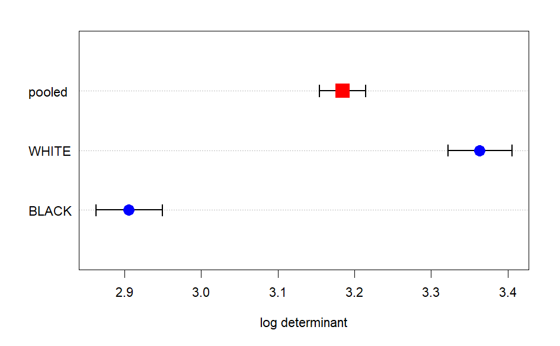

```r
plot(boxq1)
```

### Model Train with k-fold Cross Validation

```r
fit_formula_lda = winner ~ rated + turns + pace_type + WOE_W1 + WOE_B1 +
  Rating_WB + opening_strategy + WOE_op_name

lda_q1 = lda(fit_formula_lda, data=train_q1)
lda_q1
```

```
Call:
lda(fit_formula_lda, data = train_q1)

Prior probabilities of groups:
    BLACK     WHITE
0.4774669 0.5225331

Group means:
      ratedTRUE    turns pace_typeBULLET pace_typeSTANDARD       WOE_W1       WOE_B1
BLACK 0.8305975 61.37065     0.006237689         0.2879186 -0.011232213 -0.010925912
WHITE 0.8206090 58.36313     0.004949753         0.2947353  0.009043658  0.009483914
      Rating_WB opening_strategyNO_DEFENSE WOE_op_name
BLACK 0.9562675                  0.4356533 -0.02723652
WHITE 1.0721423                  0.4259787  0.02757331

Coefficients of linear discriminants:
                                    LD1
ratedTRUE                   0.059126099
turns                      -0.002715038
pace_typeBULLET             0.041591946
pace_typeSTANDARD           0.028164511
WOE_W1                      0.253935024
WOE_B1                      0.254046006
Rating_WB                   6.158825882
opening_strategyNO_DEFENSE -0.017624677
WOE_op_name                 0.902474558
```

```r
set.seed(5)
folds = createFolds(train_q1$winner, k=10)

misclassification = function(index){
  temp_train = train_q1[-index,]
  temp_test = train_q1[index,]
  temp_model = lda(fit_formula_lda, data = temp_train)
  temp_predicts = predict(temp_model, temp_test, type = "class")$class
  temp_actuals = temp_test$winner
  return(1-mean(temp_predicts==temp_actuals))
}

misclas_rate = lapply(folds, misclassification)
CV_Error_LDA = mean(as.numeric(misclas_rate))
CV_Error_LDA
```

```
[1] 0.3451653
```

### Model Performance on Test Dataset

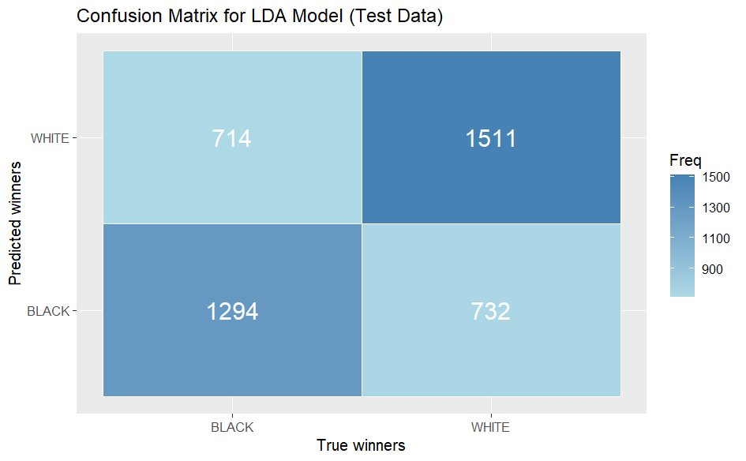

```r
lda_pred_class = predict(lda_q1, test_q1, type = "class")$class

conf_mat_ldaq1 = confusionMatrix(data = lda_pred_class,
                                 reference = test_q1$winner)

ggplot(as.data.frame(conf_mat_ldaq1$table), aes(x = Reference, y = Prediction)) +
  geom_tile(aes(fill = Freq), colour = "white") +
  scale_fill_gradient(low = "lightblue", high = "steelblue") +
  geom_text(aes(label = Freq), color = "white", size = 6) +
  xlab("True winners") +
  ylab("Predicted winners") +
  ggtitle("Confusion Matrix for LDA Model (Test Data)")
```

```r
Accuracy_LDA_Q1 = sum(diag(conf_mat_ldaq1$table)) / sum(conf_mat_ldaq1$table)
paste('The Accuracy value of LDA is:', Accuracy_LDA_Q1, sep = ' ')
```

```
[1] "The Accuracy value of LDA is: 0.65984474241355"
```

#### Performance Metrics

```r
table = table(lda_pred_class, actual_q1)
confusionMatrix(table, positive = 'WHITE')
```

```
Confusion Matrix and Statistics

              actual_q1
lda_pred_class BLACK WHITE
         BLACK  1294   732
         WHITE   714  1511

               Accuracy : 0.6598
                 95% CI : (0.6454, 0.6741)
    No Information Rate : 0.5276
    P-Value [Acc > NIR] : <2e-16

                  Kappa : 0.3179

 Mcnemar's Test P-Value : 0.6548

            Sensitivity : 0.6737
            Specificity : 0.6444
         Pos Pred Value : 0.6791
         Neg Pred Value : 0.6387
             Prevalence : 0.5276
         Detection Rate : 0.3554
   Detection Prevalence : 0.5234
      Balanced Accuracy : 0.6590

       'Positive' Class : WHITE
```

#### ROC Curve and AUC Calculations

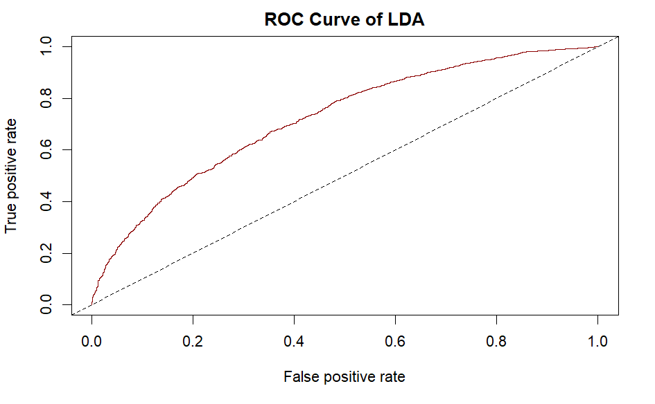

```r
pred_prob_lda = predict(lda_q1, test_q1, type='prob')
pred_prob_lda = pred_prob_lda$posterior[,2]
plot(performance(prediction(pred_prob_lda, actual_q1), "tpr", "fpr"),
     main = 'ROC Curve of LDA',
     col = 'darkred')
abline(0, 1, lty = 2)
```

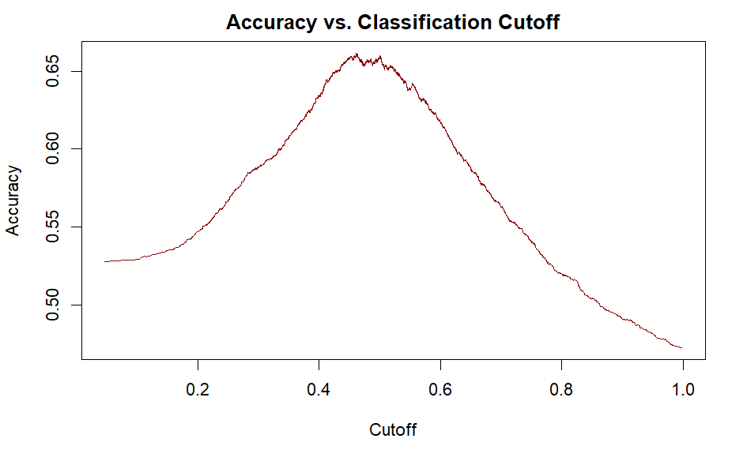

```r
plot(performance(prediction(pred_prob_lda, actual_q1), "acc"),
     main = 'Accuracy vs. Classification Cutoff',
     col = 'darkred')
```

```r
auc_lda = performance(prediction(pred_prob_lda, actual_q1), "auc")
paste('The AUC value of LDA is:', auc_lda@y.values[[1]], sep = ' ')
```

```
[1] "The AUC value of LDA is: 0.721252750922304"
```

## Quadratic Discriminant Analysis

### Additional Data Processing

Not Required

### Model Assumptions

Tested on LDA part

### Model Train with k-fold Cross Validation

```r
fit_formula_qda = winner ~ rated + turns + pace_type + WOE_W1 + WOE_B1 +
  Rating_WB + opening_strategy + WOE_op_name

qda_q1 = qda(fit_formula_qda, data = train_q1)
qda_q1
```

```
Call:
qda(fit_formula_qda, data = train_q1)

Prior probabilities of groups:
    BLACK     WHITE
0.4774669 0.5225331

Group means:
      ratedTRUE    turns pace_typeBULLET pace_typeSTANDARD       WOE_W1       WOE_B1
BLACK 0.8305975 61.37065     0.006237689         0.2879186 -0.011232213 -0.010925912
WHITE 0.8206090 58.36313     0.004949753         0.2947353  0.009043658  0.009483914
      Rating_WB opening_strategyNO_DEFENSE WOE_op_name
BLACK 0.9562675                  0.4356533 -0.02723652
WHITE 1.0721423                  0.4259787  0.02757331
```

```r
set.seed(5)
folds = createFolds(train_q1$winner, k=10)

misclassification = function(index){
  temp_train = train_q1[-index,]
  temp_test = train_q1[index,]
  temp_model = qda(fit_formula_qda, data = temp_train)
  temp_predicts = predict(temp_model, temp_test, type = "class")$class
  temp_actuals = temp_test$winner
  return(1-mean(temp_predicts==temp_actuals))
}

misclas_rate = lapply(folds, misclassification)
CV_Error_QDA = mean(as.numeric(misclas_rate))
CV_Error_QDA
```

```
[1] 0.3657014
```

### Model Performance on Test Dataset

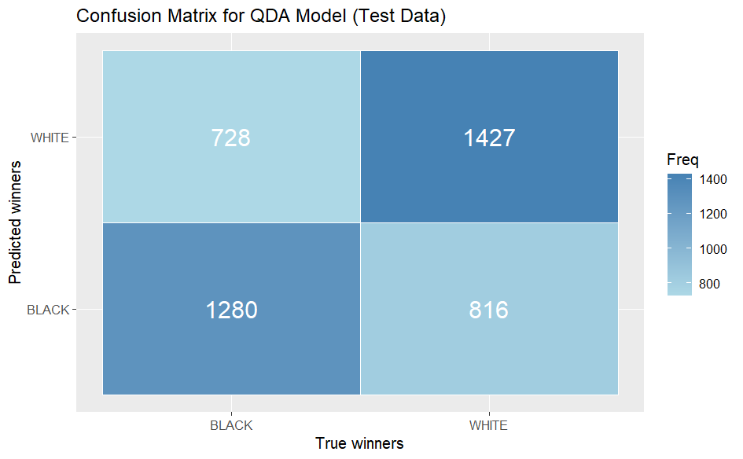

```r
qda_pred_class = predict(qda_q1, test_q1, type = "class")$class

conf_mat_qdaq1 = confusionMatrix(data = qda_pred_class,
                                 reference = test_q1$winner)

ggplot(as.data.frame(conf_mat_qdaq1$table), aes(x = Reference, y = Prediction)) +
  geom_tile(aes(fill = Freq), colour = "white") +
  scale_fill_gradient(low = "lightblue", high = "steelblue") +
  geom_text(aes(label = Freq), color = "white", size = 6) +
  xlab("True winners") +
  ylab("Predicted winners") +
  ggtitle("Confusion Matrix for QDA Model (Test Data)")
```

```r
Accuracy_QDA_Q1 = sum(diag(conf_mat_qdaq1$table)) / sum(conf_mat_qdaq1$table)
paste('The Accuracy value of QDA is:', Accuracy_QDA_Q1, sep = ' ')
```

```
[1] "The Accuracy value of QDA is: 0.636791343213362"
```

#### Performance Metrix

```r
table = table(qda_pred_class, actual_q1)
confusionMatrix(table, positive = 'WHITE')
```

```
Confusion Matrix and Statistics

              actual_q1
qda_pred_class BLACK WHITE
         BLACK  1280   816
         WHITE   728  1427

               Accuracy : 0.6368
                 95% CI : (0.6221, 0.6513)
    No Information Rate : 0.5276
    P-Value [Acc > NIR] : < 2e-16

                  Kappa : 0.273

 Mcnemar's Test P-Value : 0.02682

            Sensitivity : 0.6362
            Specificity : 0.6375
         Pos Pred Value : 0.6622
         Neg Pred Value : 0.6107
             Prevalence : 0.5276
         Detection Rate : 0.3357
   Detection Prevalence : 0.5069
      Balanced Accuracy : 0.6368

       'Positive' Class : WHITE
```

#### ROC Curve and AUC Calculations

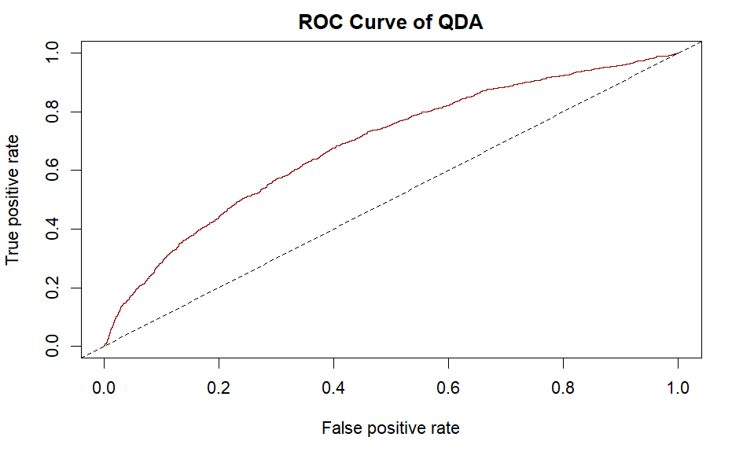

```r
pred_prob_qda = predict(qda_q1, test_q1, type='prob')
pred_prob_qda = pred_prob_qda$posterior[,2]
plot(performance(prediction(pred_prob_qda, actual_q1), "tpr", "fpr"),
     main = 'ROC Curve of QDA',
     col = 'darkred')
abline(0, 1, lty = 2)
```

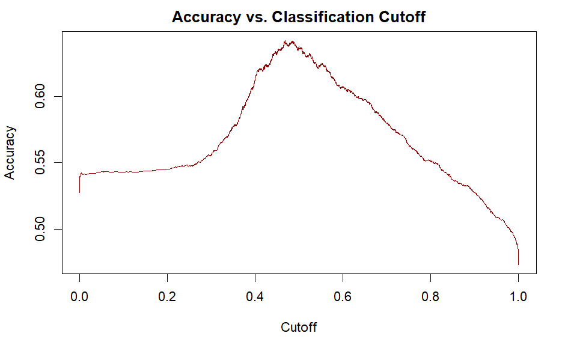

```r
plot(performance(prediction(pred_prob_qda, actual_q1), "acc"),
     main = 'Accuracy vs. Classification Cutoff',
     col = 'darkred')
```

```r
auc_qda = performance(prediction(pred_prob_qda, actual_q1), "auc")
paste('The AUC value of QDA is:', auc_qda@y.values[[1]], sep = ' ')
```

```
[1] "The AUC value of QDA is: 0.686594016266633"
```

## Question 1 Conclusion

```r
Model_Q1 = c('Recursive Partioning and Regression Tree',
             'Logistic Regression',
             'Linear Discriminant Analysis',
             'Quadratic Discriminant Analysis')

CV_Error_Q1 = c(CV_Tree_Q1,
                CV_Error_LogReg,
                CV_Error_LDA,
                CV_Error_QDA)

AUC_Q1 = c(auc_tree@y.values[[1]],
           auc_log_reg@y.values[[1]],
           auc_lda@y.values[[1]],
           auc_qda@y.values[[1]])

ACC_Q1 = c(Accuracy_Tree_Q1,
           Accuracy_LogReg_Q1,
           Accuracy_LDA_Q1,
           Accuracy_QDA_Q1)

Assumptions_Q1 = c('No Assumptions',
                   'All Passed',
                   'All Failed (Normality & Equal Cov.)',
                   'All Failed (Normality)')

Result_Q1 = data.frame(Models = Model_Q1,
                       CV_Error = CV_Error_Q1,
                       ACC = ACC_Q1,
                       AUC = AUC_Q1,
                       Assumptions = Assumptions_Q1)

Result_Q1
```

| Models | CV_Error | ACC | AUC | Assumptions |
| --- | --- | --- | --- | --- |
| Recursive Partioning and Regression Tree | 0.3749493 | 0.6311456 | 0.6902900 | No Assumptions |
| Logistic Regression | 0.3456113 | 0.6574924 | 0.7209019 | All Passed |
| Linear Discriminant Analysis | 0.3451653 | 0.6598447 | 0.7212528 | All Failed (Normality & Equal Cov.) |
| Quadratic Discriminant Analysis | 0.3657014 | 0.6367913 | 0.6865940 | All Failed (Normality) |

```r
# rm(list=ls()[! ls() %in% c('chess_df_q1', 'chess_df_q2', 'chess_df_q3',
#                            'train_q1', 'test_q1', 'train_q1_cleaned', 'IV')])
```

# Question 2

## Stratified Train - Test Split

```r
set.seed(5)
idx = createDataPartition(chess_df_q2$rating_bins, p = .75, list = FALSE)
train_q2 <- chess_df_q2[ idx,]
test_q2  <- chess_df_q2[-idx,]
```

## Decision Tree

### Additional Data Processing

Not Required

### Model Assumptions

No assumption to test

### Model Train with k-fold Cross Validation

#### Model Train

```r
fit_formula_tree = victory_status ~ rated + turns + pace_type + W1 + B1 +
  Rating_WB + rating_bins + opening_strategy
tree_Q2 = rpart(fit_formula_tree,
                data = train_q2,
                method="class")
```

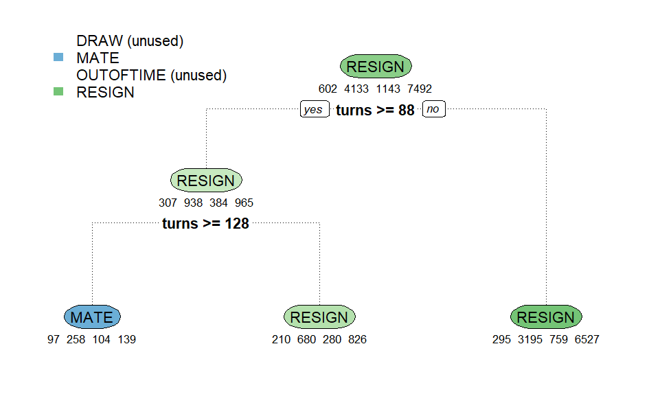

```r
rpart.plot(tree_Q2,
           type = 2,
           extra =1,
           under = TRUE,
           branch.lty=3,
           digits = 4)
```

#### Cross Validation Error

```r
set.seed(5)
folds = createFolds(train_q2$victory_status, k=10)

misclassification<-function(idx){
  temp_train = train_q2[-idx,]
  temp_test = train_q2[idx,]
  tree_model = rpart(fit_formula_tree, data = temp_train, method="class")
  pred = predict(tree_model,temp_test, type="class")
  actual = temp_test$victory_status
  conf = table(pred, actual)
  1 - sum(diag(conf)) / sum(conf)
}
CV_Tree_Q2 = mean(as.numeric(lapply(folds, misclassification)))
CV_Tree_Q2
```

```
[1] 0.4358259
```

### Model Performance on Test Dataset

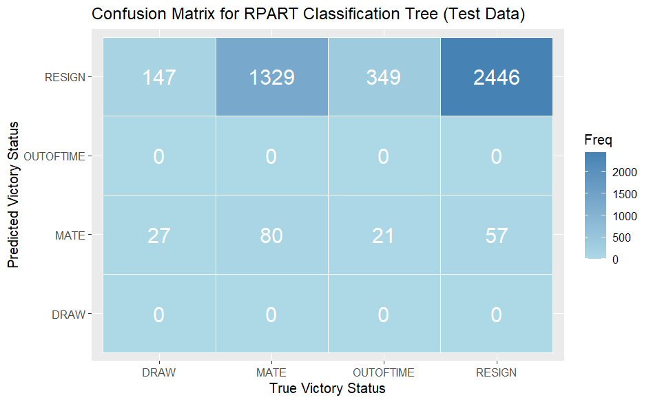

```r
q2_tree_pred = predict(tree_Q2, test_q2, type = 'class')
actual_q2 = test_q2$victory_status
table = table(q2_tree_pred, actual_q2)
ggplot(as.data.frame(table), aes(x = actual_q2, y = q2_tree_pred)) +
  geom_tile(aes(fill = Freq), colour = "white") +
  scale_fill_gradient(low = "lightblue", high = "steelblue") +
  geom_text(aes(label = Freq), color = "white", size = 6) +
  xlab("True Victory Status") +
  ylab("Predicted Victory Status") +
  ggtitle("Confusion Matrix for RPART Classification Tree (Test Data)")
```

```r
Accuracy_Tree_Q2 = sum(diag(table)) / sum(table)
paste('The Accuracy value of RPART Tree is:', Accuracy_Tree_Q2, sep = ' ')
```

```
[1] "The Accuracy value of RPART Tree is: 0.566876122082585"
```

#### Performance Metrics

```r
confusionMatrix(table)
```

```
Confusion Matrix and Statistics

            actual_q2
q2_tree_pred DRAW MATE OUTOFTIME RESIGN
   DRAW         0    0         0      0
   MATE        27   80        21     57
   OUTOFTIME    0    0         0      0
   RESIGN     147 1329       349   2446

Overall Statistics

               Accuracy : 0.5669
                 95% CI : (0.5522, 0.5815)
    No Information Rate : 0.5617
    P-Value [Acc > NIR] : 0.2486

                  Kappa : 0.0342

 Mcnemar's Test P-Value : NA

Statistics by Class:

                     Class: DRAW Class: MATE Class: OUTOFTIME Class: RESIGN
Sensitivity              0.00000     0.05678          0.00000       0.97723
Specificity              1.00000     0.96554          1.00000       0.06554
Pos Pred Value               NaN     0.43243              NaN       0.57270
Neg Pred Value           0.96095     0.68883          0.91697       0.69189
Prevalence               0.03905     0.31620          0.08303       0.56171
Detection Rate           0.00000     0.01795          0.00000       0.54892
Detection Prevalence     0.00000     0.04152          0.00000       0.95848
Balanced Accuracy        0.50000     0.51116          0.50000       0.52138
```

## Multinomial Regression

### Additional Data Processing

Not Required

### Model Assumptions

#### Independence and Multicollinearity

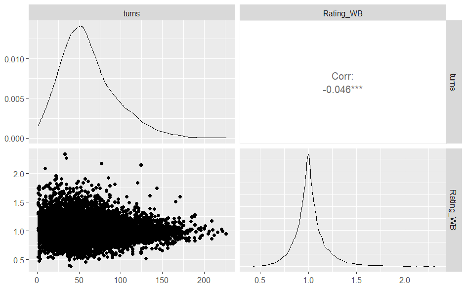

```r
my_data = train_q2 %>% dplyr::select(c(turns, Rating_WB))
ggpairs(my_data)
```

### Model Train with k-fold Cross Validation

#### Model Train

All Variables are significant

```r
fit_formula_mnom = victory_status ~ rated + turns + pace_type +
  Rating_WB + opening_strategy

mnom_Q2 = vglm(fit_formula_mnom,
               family=multinomial(),
               data = train_q2)
```

```r
summary(mnom_Q2)
```

```
Call:
vglm(formula = fit_formula_mnom, family = multinomial(), data = train_q2)

Coefficients:
                               Estimate Std. Error z value Pr(>|z|)
(Intercept):1                -4.3354248  0.3308928 -13.102  < 2e-16 ***
(Intercept):2                -1.7118948  0.1451238 -11.796  < 2e-16 ***
(Intercept):3                -2.6997151  0.2421259 -11.150  < 2e-16 ***
ratedTRUE:1                  -0.3469667  0.1084112  -3.200  0.00137 **
ratedTRUE:2                   0.0084075  0.0524709   0.160  0.87270
ratedTRUE:3                  -0.2343238  0.0839604  -2.791  0.00526 **
turns:1                       0.0258913  0.0011487  22.540  < 2e-16 ***
turns:2                       0.0120060  0.0006248  19.216  < 2e-16 ***
turns:3                       0.0181378  0.0009316  19.469  < 2e-16 ***
pace_typeBULLET:1             0.1439896  0.7352640   0.196  0.84474
pace_typeBULLET:2             0.1973652  0.2774295   0.711  0.47683
pace_typeBULLET:3             0.9722315  0.3310767   2.937  0.00332 **
pace_typeSTANDARD:1           0.2739729  0.0911485   3.006  0.00265 **
pace_typeSTANDARD:2          -0.0235315  0.0431508  -0.545  0.58553
pace_typeSTANDARD:3          -0.6149372  0.0807801  -7.612 2.69e-14 ***
Rating_WB:1                   0.2464665  0.2836485   0.869  0.38489
Rating_WB:2                   0.2833689  0.1227653   2.308  0.02099 *
Rating_WB:3                  -0.0099710  0.2097603  -0.048  0.96209
opening_strategyNO_DEFENSE:1 -0.0262997  0.0885309  -0.297  0.76641
opening_strategyNO_DEFENSE:2  0.2457064  0.0396527   6.196 5.77e-10 ***
opening_strategyNO_DEFENSE:3  0.0356010  0.0656271   0.542  0.58749
---
Signif. codes:  0 ‘***’ 0.001 ‘**’ 0.01 ‘*’ 0.05 ‘.’ 0.1 ‘ ’ 1

Names of linear predictors: log(mu[,1]/mu[,4]), log(mu[,2]/mu[,4]), log(mu[,3]/mu[,4])

Residual deviance: 26717.72 on 40089 degrees of freedom

Log-likelihood: -13358.86 on 40089 degrees of freedom

Number of Fisher scoring iterations: 6

Warning: Hauck-Donner effect detected in the following estimate(s):
'(Intercept):1', '(Intercept):3'


Reference group is level  4  of the response
```

#### Goodness of Fit Test

p-value is less than 0.05.

```r
1-pchisq(sum(resid(mnom_Q2,
                   type="pearson")^2),
         df.residual(mnom_Q2))
```

```
[1] 3.094665e-07
```

#### Cross Validation

```r
set.seed(5)
folds = createFolds(train_q2$victory_status, k=10)

mcr.mnr = function(idx){
  Train = train_q2[-idx,]
  Test = train_q2[idx,]
  fitmnr = vglm(fit_formula_mnom,
                family=multinomial(),
                data = Train)
  pred_victor = predict(fitmnr, Test, type = "response")
  predictmnr2 = colnames(pred_victor)[apply(pred_victor,1,which.max)]
  return(mean(predictmnr2 != Test$victory_status))
}

CV_MNom_Q2 = mean(as.numeric(lapply(folds,mcr.mnr)))
CV_MNom_Q2
```

```
[1] 0.4314145
```

### Model Performance on Test Dataset

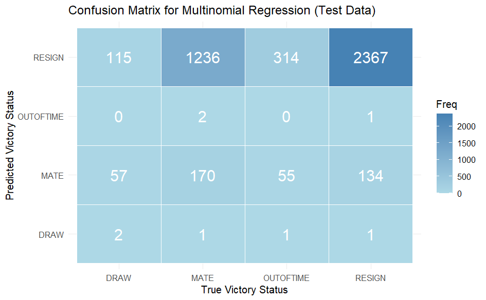

```r
Pred_Prob_MNOM = predict(mnom_Q2, test_q2, type="response")
Pred_Class_MNOM = colnames(Pred_Prob_MNOM)[apply(Pred_Prob_MNOM,1,which.max)]

cf_multi = confusionMatrix(factor(Pred_Class_MNOM), test_q2$victory_status)
cf_multi_df <- as.data.frame(cf_multi$table)

ggplot(cf_multi_df, aes(x = Reference, y = Prediction)) +
  geom_tile(aes(fill = Freq), colour = "white") +
  scale_fill_gradient(low = "light blue",
                      high = "steel blue",
                      space = "Lab",
                      na.value = "grey50",
                      guide = "colourbar",
                      aesthetics = "fill")+
  geom_text(aes(label = Freq),
            color = "white",
            size = 6) +
  ggtitle("Confusion Matrix for Multinomial Regression (Test Data)") +
  xlab("True Victory Status") +
  ylab("Predicted Victory Status") +
  theme_minimal()
```

```r
Accuracy_MNom_Q2 = sum(diag(cf_multi$table)) / sum(cf_multi$table)
paste('The Accuracy value of MultiNomial Model is:', Accuracy_MNom_Q2, sep = ' ')
```

```
[1] "The Accuracy value of MultiNomial Model is: 0.569793536804309"
```

#### Performance Metrics

```r
cf_multi
```

```
Confusion Matrix and Statistics

           Reference
Prediction  DRAW MATE OUTOFTIME RESIGN
  DRAW         2    1         1      1
  MATE        57  170        55    134
  OUTOFTIME    0    2         0      1
  RESIGN     115 1236       314   2367

Overall Statistics

               Accuracy : 0.5698
                 95% CI : (0.5551, 0.5844)
    No Information Rate : 0.5617
    P-Value [Acc > NIR] : 0.1419

                  Kappa : 0.069

 Mcnemar's Test P-Value : <2e-16

Statistics by Class:

                     Class: DRAW Class: MATE Class: OUTOFTIME Class: RESIGN
Sensitivity            0.0114943     0.12065        0.0000000        0.9457
Specificity            0.9992994     0.91926        0.9992658        0.1475
Pos Pred Value         0.4000000     0.40865        0.0000000        0.5871
Neg Pred Value         0.9613570     0.69332        0.9169099        0.6792
Prevalence             0.0390485     0.31620        0.0830341        0.5617
Detection Rate         0.0004488     0.03815        0.0000000        0.5312
Detection Prevalence   0.0011221     0.09336        0.0006732        0.9048
Balanced Accuracy      0.5053968     0.51996        0.4996329        0.5466
```

## Linear Discriminant Analysis

### Additional Data Processing

Not Required.

### Model Assumptions

#### Normality with Actual Data

```r
Q2.outoftime = subset(chess_df_q2, victory_status == "OUTOFTIME")
Q2.resign = subset(chess_df_q2,victory_status == "RESIGN")
Q2.mate = subset(chess_df_q2,victory_status == "MATE")
Q2.draw = subset(chess_df_q2,victory_status == "DRAW")
```

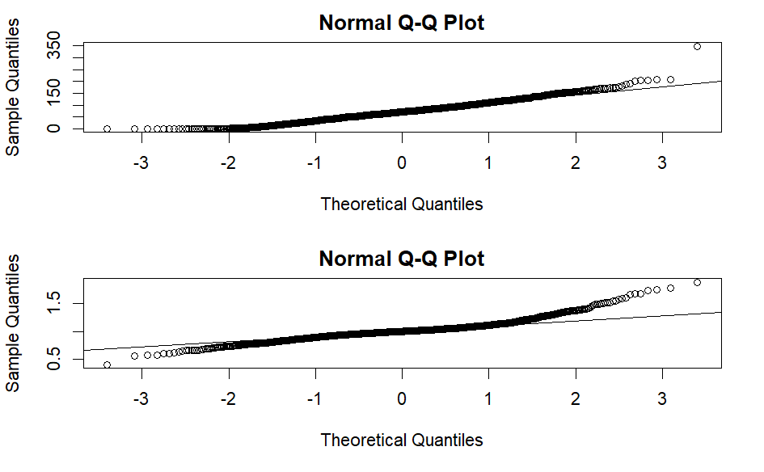

```r
variable_2 = c("turns","Rating_WB")
par(mfrow = c(2,1))

for(i in variable_2) {
  qqnorm(Q2.outoftime[[i]]);qqline(Q2.outoftime[[i]])}
```

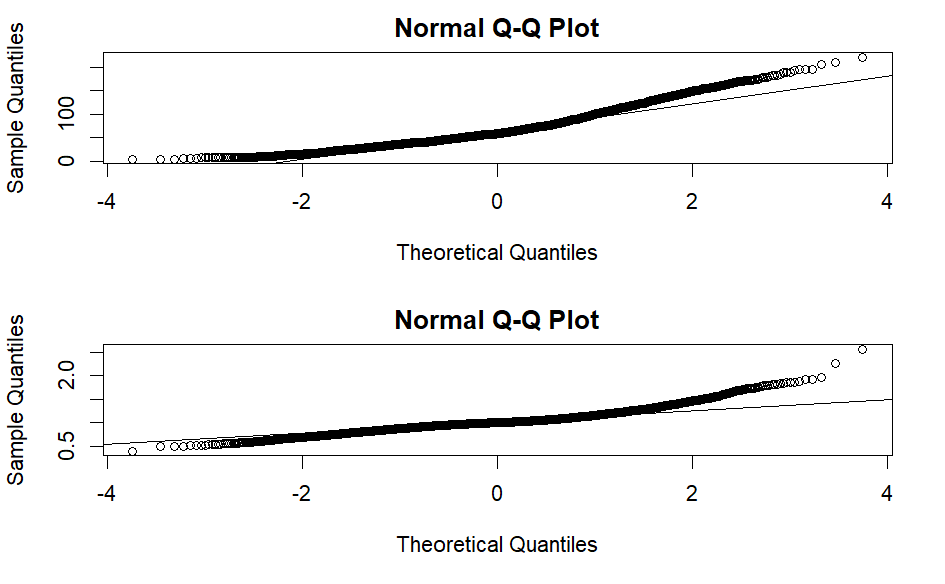

```r
par(mfrow = c(2,1))

for(i in variable_2) {
  qqnorm(Q2.mate[[i]]);qqline(Q2.mate[[i]])}
```

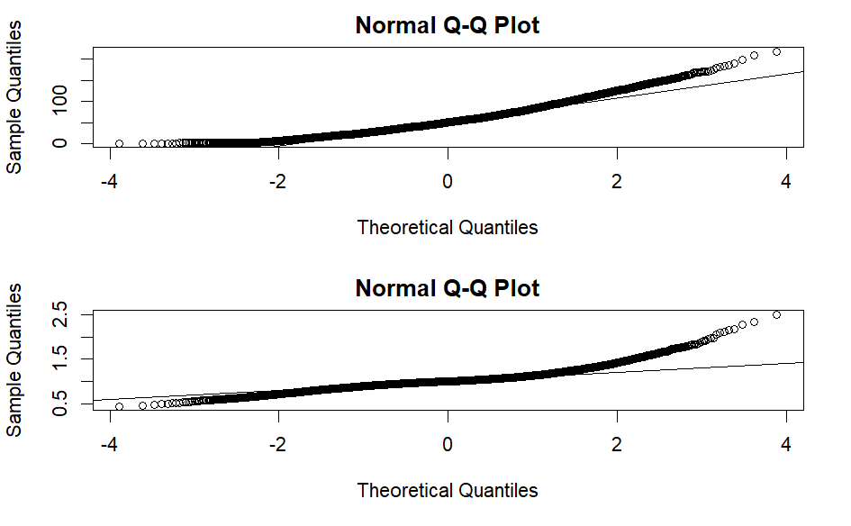

```r
par(mfrow = c(2,1))

for(i in variable_2) {
  qqnorm(Q2.resign[[i]]);qqline(Q2.resign[[i]])}
```

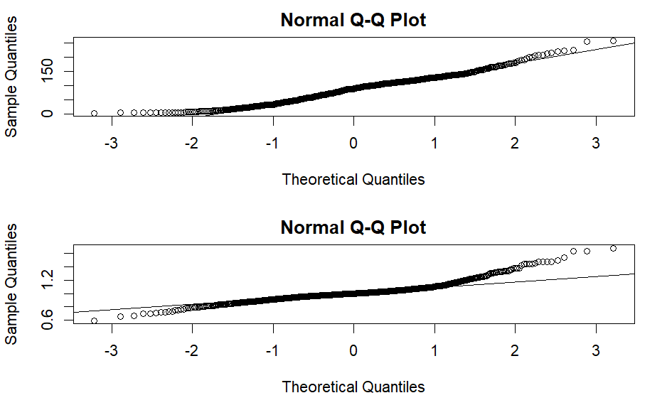

```r
par(mfrow = c(2,1))

for(i in variable_2) {
  qqnorm(Q2.draw[[i]]);qqline(Q2.draw[[i]])}
```

```r
jarque.bera.test(Q2.outoftime$turns)
```

```
    Jarque Bera Test

data:  Q2.outoftime$turns
X-squared = 231.85, df = 2, p-value < 2.2e-16
```

```r
jarque.bera.test(Q2.outoftime$Rating_WB)
```

```
    Jarque Bera Test

data:  Q2.outoftime$Rating_WB
X-squared = 1322.8, df = 2, p-value < 2.2e-16
```

```r
jarque.bera.test(Q2.mate$turns)
```

```
    Jarque Bera Test

data:  Q2.mate$turns
X-squared = 932.03, df = 2, p-value < 2.2e-16
```

```r
jarque.bera.test(Q2.mate$Rating_WB)
```

```
    Jarque Bera Test

data:  Q2.mate$Rating_WB
X-squared = 5177.9, df = 2, p-value < 2.2e-16
```

```r
jarque.bera.test(Q2.resign$turns)
```

```
    Jarque Bera Test

data:  Q2.resign$turns
X-squared = 1412.6, df = 2, p-value < 2.2e-16
```

```r
jarque.bera.test(Q2.resign$Rating_WB)
```

```
    Jarque Bera Test

data:  Q2.resign$Rating_WB
X-squared = 18027, df = 2, p-value < 2.2e-16
```

```r
jarque.bera.test(Q2.draw$turns)
```

```
    Jarque Bera Test

data:  Q2.draw$turns
X-squared = 10.438, df = 2, p-value = 0.005411
```

```r
jarque.bera.test(Q2.draw$Rating_WB)
```

```
    Jarque Bera Test

data:  Q2.draw$Rating_WB
X-squared = 603.66, df = 2, p-value < 2.2e-16
```

#### Normality with Log Transform

```r
jarque.bera.test(log(Q2.outoftime$turns))
```

```
    Jarque Bera Test

data:  log(Q2.outoftime$turns)
X-squared = 3392.8, df = 2, p-value < 2.2e-16
```

```r
jarque.bera.test(log(Q2.outoftime$Rating_WB))
```

```
    Jarque Bera Test

data:  log(Q2.outoftime$Rating_WB)
X-squared = 631.86, df = 2, p-value < 2.2e-16
```

```r
jarque.bera.test(log(Q2.mate$turns))
```

```
    Jarque Bera Test

data:  log(Q2.mate$turns)
X-squared = 766.08, df = 2, p-value < 2.2e-16
```

```r
jarque.bera.test(log(Q2.mate$Rating_WB))
```

```
    Jarque Bera Test

data:  log(Q2.mate$Rating_WB)
X-squared = 1012.9, df = 2, p-value < 2.2e-16
```

```r
jarque.bera.test(log(Q2.resign$turns))
```

```
    Jarque Bera Test

data:  log(Q2.resign$turns)
X-squared = 11443, df = 2, p-value < 2.2e-16
```

```r
jarque.bera.test(log(Q2.resign$Rating_WB))
```

```
    Jarque Bera Test

data:  log(Q2.resign$Rating_WB)
X-squared = 3448.7, df = 2, p-value < 2.2e-16
```

```r
jarque.bera.test(log(Q2.draw$turns))
```

```
    Jarque Bera Test

data:  log(Q2.draw$turns)
X-squared = 644.9, df = 2, p-value < 2.2e-16
```

```r
jarque.bera.test(log(Q2.draw$Rating_WB))
```

```
    Jarque Bera Test

data:  log(Q2.draw$Rating_WB)
X-squared = 197.64, df = 2, p-value < 2.2e-16
```

#### Equal Covariance

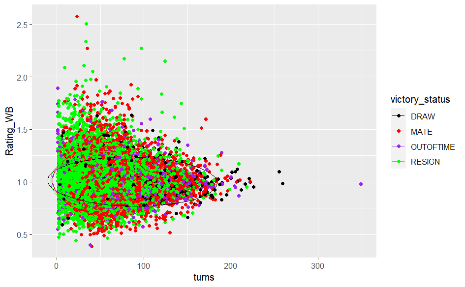

```r
ggplot(chess_df_q2, aes(x = turns, y = Rating_WB, col = victory_status)) +
    geom_point() +
    stat_ellipse() +
    scale_color_manual(values = c("black", "red", "purple", "green"))
```

```r
new_data = chess_df_q2 %>% dplyr::select(c(turns, Rating_WB))
boxq2 = heplots::boxM(new_data, chess_df_q2$victory_status)
boxq2
```

```
    Box's M-test for Homogeneity of Covariance Matrices

data:  new_data
Chi-Sq (approx.) = 708.34, df = 9, p-value < 2.2e-16
```

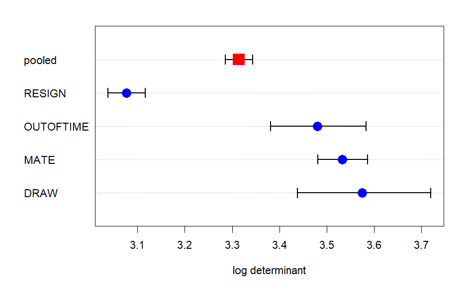

```r
plot(boxq2)
```

### Model Train with k-fold Cross Validation

```r
fit_formula_lda = victory_status ~ rated + turns + pace_type + W1 + B1 +
  Rating_WB + opening_strategy

lda_q2 = lda(fit_formula_lda, data=train_q2)
lda_q2
```

```
Call:
lda(fit_formula_lda, data = train_q2)

Prior probabilities of groups:
      DRAW       MATE  OUTOFTIME     RESIGN
0.04502618 0.30912491 0.08548990 0.56035901

Group means:
          ratedTRUE    turns pace_typeBULLET pace_typeSTANDARD        W1a4        W1b3
DRAW      0.7906977 84.99003     0.003322259         0.3621262 0.000000000 0.011627907
MATE      0.8303895 66.17106     0.005081055         0.2978466 0.001693685 0.007984515
OUTOFTIME 0.8136483 74.00350     0.011373578         0.1898513 0.001749781 0.010498688
RESIGN    0.8186065 54.32395     0.004938601         0.3103310 0.000934330 0.007608115
                 W1b4        W1c3       W1c4        W1d3      W1d4       W1e3      W1e4
DRAW      0.004983389 0.000000000 0.02990033 0.001661130 0.2292359 0.01827243 0.6295681
MATE      0.003145415 0.002661505 0.03145415 0.007984515 0.2167917 0.02661505 0.6290830
OUTOFTIME 0.004374453 0.002624672 0.03849519 0.003499563 0.2248469 0.01924759 0.6246719
RESIGN    0.004538174 0.003203417 0.03630539 0.005339028 0.2333155 0.01641751 0.6330753
                  W1f3        W1f4        W1g3        W1g4         W1h3         W1h4
DRAW      0.0033222591 0.018272425 0.001661130 0.003322259 0.0000000000 0.0000000000
MATE      0.0012097750 0.008710380 0.012823615 0.003387370 0.0012097750 0.0021775950
OUTOFTIME 0.0008748906 0.006124234 0.013123360 0.001749781 0.0000000000 0.0026246719
RESIGN    0.0013347571 0.006540310 0.007074212 0.001468233 0.0008008542 0.0006673785
                 W1Na3       W1Nc3      W1Nf3        W1Nh3        B1a5        B1a6
DRAW      0.0000000000 0.001661130 0.04651163 0.0000000000 0.003322259 0.003322259
MATE      0.0002419550 0.007258650 0.03266392 0.0007258650 0.001693685 0.002177595
OUTOFTIME 0.0000000000 0.004374453 0.03937008 0.0008748906 0.000000000 0.001749781
RESIGN    0.0002669514 0.004404698 0.03550454 0.0002669514 0.001067806 0.002402563
                  B1b5       B1b6      B1c5       B1c6      B1d5       B1d6      B1e5
DRAW      0.0000000000 0.01495017 0.1461794 0.04318937 0.1727575 0.02990033 0.3139535
MATE      0.0016936850 0.01258166 0.1233970 0.03024437 0.1921123 0.02709896 0.3796274
OUTOFTIME 0.0008748906 0.01574803 0.1539808 0.04024497 0.1618548 0.03062117 0.3324584
RESIGN    0.0010678057 0.01268019 0.1558996 0.03830753 0.1831287 0.02816337 0.3367592
               B1e6        B1f5        B1f6         B1g5       B1g6        B1h5
DRAW      0.1046512 0.011627907 0.000000000 0.0000000000 0.01993355 0.000000000
MATE      0.1035567 0.005564965 0.001935640 0.0014517300 0.01645294 0.001451730
OUTOFTIME 0.1023622 0.006124234 0.004374453 0.0000000000 0.02099738 0.001749781
RESIGN    0.1045115 0.009076348 0.001468233 0.0006673785 0.01922050 0.001067806
                B1h6        B1Na6      B1Nc6      B1Nf6        B1Nh6 Rating_WB
DRAW      0.00000000 0.0000000000 0.01827243 0.11794020 0.0000000000  1.016302
```

[output cut: 45 more lines]

```
B1f6                        3.81470182 15.927135252  0.827749729
B1g5                        4.80636206 22.901864275  1.163201060
B1g6                        5.07686371 18.857317998 -2.685350088
B1h5                        4.49931120 18.167871874  0.542905324
B1h6                        5.96444170 21.992920436  0.147516323
B1Na6                       2.37418890 16.933657046  2.353417970
B1Nc6                       4.37940194 19.008824364 -0.907944746
B1Nf6                       4.86839856 19.071890631 -3.316580386
B1Nh6                       3.51886512 20.729898012  2.334437038
Rating_WB                  -0.24881999  0.973366581  0.380857151
opening_strategyNO_DEFENSE -0.06836880  0.396543984  0.470178403

Proportion of trace:
   LD1    LD2    LD3
0.7843 0.1148 0.1008
```

```r
set.seed(5)
folds = createFolds(train_q2$victory_status, k=10)

misclassification = function(index){
  temp_train = train_q2[-index,]
  temp_test = train_q2[index,]
  temp_model = lda(fit_formula_lda, data = temp_train)
  temp_predicts = predict(temp_model, temp_test, type = "class")$class
  temp_actuals = temp_test$victory_status
  return(1-mean(temp_predicts==temp_actuals))
}

misclas_rate = lapply(folds, misclassification)
CV_LDA_Q2 = mean(as.numeric(misclas_rate))
CV_LDA_Q2
```

```
[1] 0.4342535
```

### Model Performance on Test Dataset

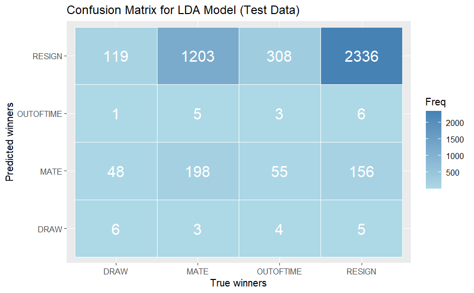

```r
lda_pred_class = predict(lda_q2, test_q2, type = "class")$class

conf_mat_ldaq2 = confusionMatrix(data = lda_pred_class,
                                 reference = test_q2$victory_status)

ggplot(as.data.frame(conf_mat_ldaq2$table), aes(x = Reference, y = Prediction)) +
  geom_tile(aes(fill = Freq), colour = "white") +
  scale_fill_gradient(low = "lightblue", high = "steelblue") +
  geom_text(aes(label = Freq), color = "white", size = 6) +
  xlab("True winners") +
  ylab("Predicted winners") +
  ggtitle("Confusion Matrix for LDA Model (Test Data)")
```

```r
Accuracy_LDA_Q2 = sum(diag(conf_mat_ldaq2$table)) / sum(conf_mat_ldaq2$table)
paste('The Accuracy value of LDA is:', Accuracy_LDA_Q2, sep = ' ')
```

```
[1] "The Accuracy value of LDA is: 0.570691202872531"
```

#### Performance Metrics

```r
table = table(lda_pred_class, actual_q2)
confusionMatrix(table, positive = 'WHITE')
```

```
Confusion Matrix and Statistics

              actual_q2
lda_pred_class DRAW MATE OUTOFTIME RESIGN
     DRAW         6    3         4      5
     MATE        48  198        55    156
     OUTOFTIME    1    5         3      6
     RESIGN     119 1203       308   2336

Overall Statistics

               Accuracy : 0.5707
                 95% CI : (0.556, 0.5853)
    No Information Rate : 0.5617
    P-Value [Acc > NIR] : 0.1165

                  Kappa : 0.0811

 Mcnemar's Test P-Value : <2e-16

Statistics by Class:

                     Class: DRAW Class: MATE Class: OUTOFTIME Class: RESIGN
Sensitivity             0.034483     0.14053        0.0081081        0.9333
Specificity             0.997198     0.91500        0.9970631        0.1654
Pos Pred Value          0.333333     0.43326        0.2000000        0.5890
Neg Pred Value          0.962145     0.69717        0.9173610        0.6592
Prevalence              0.039048     0.31620        0.0830341        0.5617
Detection Rate          0.001346     0.04443        0.0006732        0.5242
Detection Prevalence    0.004039     0.10256        0.0033662        0.8900
Balanced Accuracy       0.515840     0.52776        0.5025856        0.5493
```

## Quadratic Discriminant Analysis

### Additional Data Processing

Not Required

### Model Assumptions

Tested on LDA part

### Model Train with k-fold Cross Validation

Error in qda.default(x, grouping, ...) : rank deficiency in group DRAW. W1 and B1 eliminated.

```r
fit_formula_qda = victory_status ~ rated + turns + pace_type + Rating_WB + opening_strategy

qda_q2 = qda(fit_formula_qda, data = train_q2)
qda_q2
```

```
Call:
qda(fit_formula_qda, data = train_q2)

Prior probabilities of groups:
      DRAW       MATE  OUTOFTIME     RESIGN
0.04502618 0.30912491 0.08548990 0.56035901

Group means:
          ratedTRUE    turns pace_typeBULLET pace_typeSTANDARD Rating_WB
DRAW      0.7906977 84.99003     0.003322259         0.3621262  1.016302
MATE      0.8303895 66.17106     0.005081055         0.2978466  1.019413
OUTOFTIME 0.8136483 74.00350     0.011373578         0.1898513  1.011387
RESIGN    0.8186065 54.32395     0.004938601         0.3103310  1.015583
          opening_strategyNO_DEFENSE
DRAW                       0.3970100
MATE                       0.4674571
OUTOFTIME                  0.4164479
RESIGN                     0.4148425
```

```r
set.seed(5)
folds = createFolds(train_q2$victory_status, k=10)

misclassification = function(index){
  temp_train = train_q2[-index,]
  temp_test = train_q2[index,]
  temp_model = qda(fit_formula_qda, data = temp_train)
  temp_predicts = predict(temp_model, temp_test, type = "class")$class
  temp_actuals = temp_test$victory_status
  return(1-mean(temp_predicts==temp_actuals))
}

misclas_rate = lapply(folds, misclassification)
CV_Error_QDA = mean(as.numeric(misclas_rate))
CV_Error_QDA
```

```
[1] 0.4397944
```

### Model Performance on Test Dataset

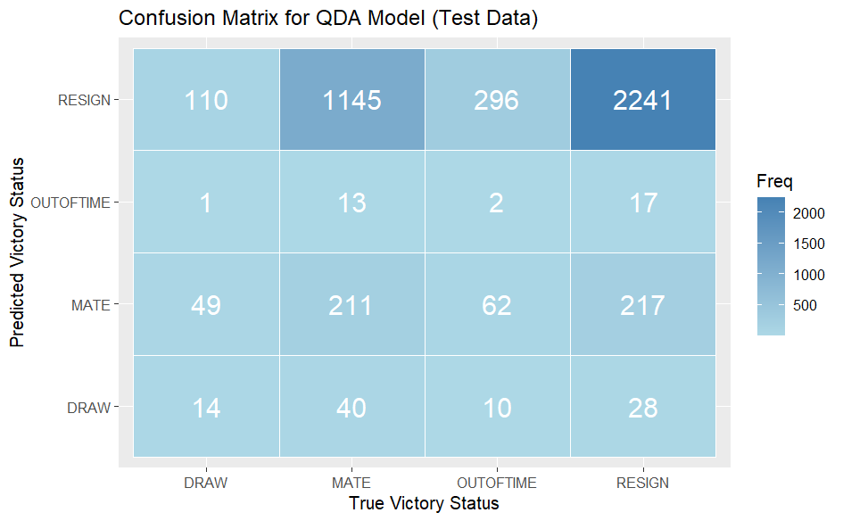

```r
qda_pred_class = predict(qda_q2, test_q2, type = "class")$class

conf_mat_qdaq2 = confusionMatrix(data = qda_pred_class,
                                 reference = test_q2$victory_status)

ggplot(as.data.frame(conf_mat_qdaq2$table), aes(x = Reference, y = Prediction)) +
  geom_tile(aes(fill = Freq), colour = "white") +
  scale_fill_gradient(low = "lightblue", high = "steelblue") +
  geom_text(aes(label = Freq), color = "white", size = 6) +
  xlab("True Victory Status") +
  ylab("Predicted Victory Status") +
  ggtitle("Confusion Matrix for QDA Model (Test Data)")
```

```r
Accuracy_QDA_Q2 = sum(diag(conf_mat_qdaq2$table)) / sum(conf_mat_qdaq2$table)
paste('The Accuracy value of QDA is:', Accuracy_QDA_Q2, sep = ' ')
```

```
[1] "The Accuracy value of QDA is: 0.553859964093357"
```

#### Performance Metrics

```r
table = table(qda_pred_class, actual_q2)
confusionMatrix(table)
```

```
Confusion Matrix and Statistics

              actual_q2
qda_pred_class DRAW MATE OUTOFTIME RESIGN
     DRAW        14   40        10     28
     MATE        49  211        62    217
     OUTOFTIME    1   13         2     17
     RESIGN     110 1145       296   2241

Overall Statistics

               Accuracy : 0.5539
                 95% CI : (0.5391, 0.5685)
    No Information Rate : 0.5617
    P-Value [Acc > NIR] : 0.8581

                  Kappa : 0.075

 Mcnemar's Test P-Value : <2e-16

Statistics by Class:

                     Class: DRAW Class: MATE Class: OUTOFTIME Class: RESIGN
Sensitivity             0.080460     0.14975        0.0054054        0.8953
Specificity             0.981784     0.89235        0.9924131        0.2058
Pos Pred Value          0.152174     0.39147        0.0606061        0.5910
Neg Pred Value          0.963336     0.69415        0.9167986        0.6054
Prevalence              0.039048     0.31620        0.0830341        0.5617
Detection Rate          0.003142     0.04735        0.0004488        0.5029
Detection Prevalence    0.020646     0.12096        0.0074057        0.8510
Balanced Accuracy       0.531122     0.52105        0.4989093        0.5506
```

## Question 2 Conclusion

```r
Model_Q2 = c('Recursive Partioning and Regression Tree',
             'Multinomial Regression',
             'Linear Discriminant Analysis',
             'Quadratic Discriminant Analysis')

CV_Error_Q2 = c(CV_Tree_Q2,
                CV_MNom_Q2,
                CV_LDA_Q2,
                CV_Error_QDA)

ACC_Q2 = c(Accuracy_Tree_Q2,
           Accuracy_MNom_Q2,
           Accuracy_LDA_Q2,
           Accuracy_QDA_Q2)

Assumptions_Q2 = c('No Assumptions',
                   'Passed But Goodness of Fit Failed',
                   'All Failed (Normality & Equal Cov.)',
                   'All Failed (Normality)')

Result_Q2 = data.frame(Models = Model_Q2,
                       CV_Error = CV_Error_Q2,
                       ACC = ACC_Q2,
                       Assumptions = Assumptions_Q2)

Result_Q2
```

| Models | CV_Error | ACC | Assumptions |
| --- | --- | --- | --- |
| Recursive Partioning and Regression Tree | 0.4358259 | 0.5668761 | No Assumptions |
| Multinomial Regression | 0.4314145 | 0.5697935 | Passed But Goodness of Fit Failed |
| Linear Discriminant Analysis | 0.4342535 | 0.5706912 | All Failed (Normality & Equal Cov.) |
| Quadratic Discriminant Analysis | 0.4397944 | 0.5538600 | All Failed (Normality) |

# Question 3

## Stratified Train - Test Split

```r
idx = createDataPartition(chess_df_q3$W1, p = .75, list = FALSE)
train_q3 <- chess_df_q3[ idx,]
test_q3  <- chess_df_q3[-idx,]
```

## Logistic Regression

### Additional Data Processing

Not Required

### Model Assumptions

#### Linearity

The predictor variable is not a natural numeric variable, it’s calculated WOE values depending on the W1 variable. Therefore, linearity assumption is not checked since the predictor is a quasi categorical variable.

#### Independence

There is only one predictor in this model therefore there is no other variable to check its independence. Moreover, at the beginning of this file, we removed the duplicate records to eliminate multiple matches of same players. Therefore, observations are independent of each other.

#### Outlier

The predictor variable is not a natural numeric variable, it’s calculated WOE values depending on the W1 variable. Therefore, outlier assumption is not checked since the predictor is a quasi categorical variable.

#### Multicollinearity

There is only one predictor in this model therefore there is no other variable to cause multicollinearity.

### Model Train with k-fold Cross Validation

#### Model Train

```r
fit_fomula_q3 = winner~WOE_W1
log_reg_q3 = glm(fit_fomula_q3, data = train_q3, family = 'binomial')
summary(log_reg_q3)
```

```
Call:
glm(formula = fit_fomula_q3, family = "binomial", data = train_q3)

Deviance Residuals:
   Min      1Q  Median      3Q     Max
-1.448  -1.225   1.087   1.131   1.643

Coefficients:
            Estimate Std. Error z value Pr(>|z|)
(Intercept)  0.09155    0.01776   5.155 2.53e-07 ***
WOE_W1       0.87853    0.12150   7.231 4.81e-13 ***
---
Signif. codes:  0 ‘***’ 0.001 ‘**’ 0.01 ‘*’ 0.05 ‘.’ 0.1 ‘ ’ 1

(Dispersion parameter for binomial family taken to be 1)

    Null deviance: 17668  on 12763  degrees of freedom
Residual deviance: 17613  on 12762  degrees of freedom
AIC: 17617

Number of Fisher Scoring iterations: 4
```

#### Cross Validation To Determine Best Cut-Off

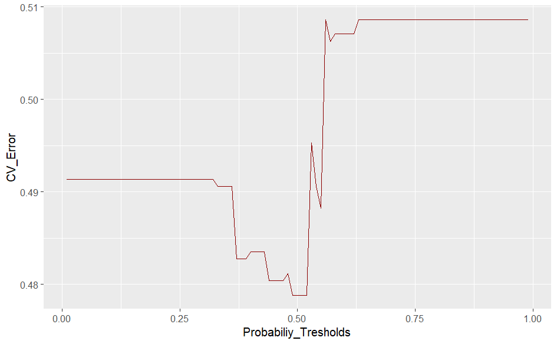

```r
set.seed(5)
folds_class = createFolds(train_q3$W1, k=10)

CV_Error = rep(0,99)

log_reg_treshold = seq(0.01, 0.99, 0.01)

for (i in 1:99){
  p_tresh = log_reg_treshold[i]
  err = rep(0,10)
  for (j in 1:10){
    assign(paste0('temp_train'), train_q3[-eval(parse(text = paste0('folds_class$Fold0',1))),])
    assign(paste0('temp_validation'), train_q3[eval(parse(text = paste0('folds_class$Fold0',1))),])
    temp_log_reg = glm(fit_fomula_q3, data = temp_train, family = 'binomial')
    temp_probs = predict(temp_log_reg, temp_validation, type="response")
    actual = temp_validation$winner
    predicted = rep('BLACK', nrow(temp_validation))
    predicted[temp_probs >= p_tresh] = 'WHITE'
    err[j] = 1-mean(predicted==actual)
  }
  CV_Error[i] = mean(err)
}

CV_Result = data.frame(Probabiliy_Tresholds = log_reg_treshold, CV_Error)

ggplot()+
  geom_line(data = CV_Result, aes(Probabiliy_Tresholds, CV_Error), colour='darkred')
```

```r
CV_Result %>% filter(CV_Error == min(CV_Error))
```

| Probabiliy_Tresholds | CV_Error |
| --- | --- |
| 0.49 | 0.4788401 |
| 0.50 | 0.4788401 |
| 0.51 | 0.4788401 |
| 0.52 | 0.4788401 |

#### Assigning Probabilities to Actual W1

```r
final_df = data.frame(WOE_W1 = IV$Tables$W1$WOE, W1 = IV$Tables$W1$W1)
final_df$Prob_Win = predict(log_reg_q3, final_df, type="response")
```

#### The Best W1 Maximizing A Win for White

```r
final_df[order(-final_df$Prob_Win),]
```

|  | WOE_W1 | W1 | Prob_Win |
| --- | --- | --- | --- |
| 4 | 0.59783700 | Nh3 | 0.6494836 |
| 5 | 0.46430561 | a3 | 0.6223323 |
| 19 | 0.24116206 | h3 | 0.5752788 |
| 8 | 0.19237189 | b4 | 0.5647735 |
| 10 | 0.14207115 | c4 | 0.5538819 |
| 3 | 0.14128826 | Nf3 | 0.5537119 |
| 9 | 0.08701138 | c3 | 0.5419006 |
| 7 | 0.05201453 | b3 | 0.5342589 |
| 14 | 0.02234115 | e4 | 0.5277668 |
| 12 | 0.00783166 | d4 | 0.5245888 |

[output cut: 10 more lines]